# Punishment Study 2.1.2 — Main Analysis

Confirmatory and Exploratory Tests of the Punitiveness Ecosystem

David G. Kamper

April 27, 2026

# Overview

This script performs the **complete main analysis** for the Punishment Study 2.1.2, covering data cleaning through hypothesis testing through exploratory follow-ups.

## Pre-registered hypotheses

- **H1**: Punitiveness is positively correlated with all correlate measures.
- **H2**: The hostile aggression cluster correlates more strongly with punitiveness than the crime concerns cluster.
- **H3**: Most correlate measures are positively intercorrelated, indicating a cohesive “punitiveness mindset.”

## Phases

1. **Phase 0** — Setup and package loading
2. **Phase 1** — Data loading, filtering, missing-data check
3. **Phase 2** — Reverse coding (metadata-driven)
4. **Phase 3** — Z-score sentencing decisions within vignette
5. **Phase 4** — Composite construction with Cronbach’s α
6. **Phase 5** — Demographics and descriptive statistics
7. **Phase 6** — Confirmatory hypothesis tests (H1, H2, H3) + FDR correction
8. **Phase 7** — Correlation tables for export
9. **Phase 8** — Vignette stability sensitivity analyses
10. **Phase 9** — Exploratory analyses (process violations, blood sports, revenge vs. vengefulness, EFA, CFA, demographic moderators)
11. **Phase 10** — Multiple regression (clusters, constructs, hierarchical)
12. **Phase 11** — Save all output files

## Output organization

All outputs are written to subdirectories of the working directory:

- `output/tables/` — CSV tables (correlations, descriptives, regression results)
- `output/figures/` — PNG figures (heatmaps, histograms, scree plots)
- `data/cleaned/` — Cleaned dataset for downstream use (e.g., NLP pipeline)

# PHASE 0: SETUP AND PACKAGE LOADING

```r
# === PATH CONFIGURATION ===
# All paths are relative to the working directory of this Rmd file.
# Set your working directory to the Analysis folder before knitting.

# Input data path
DATA_PATH <- "data/raw/Data_Final.csv"

# Output directories
OUT_TABLES  <- "output/tables"
OUT_FIGURES <- "output/figures"
OUT_DATA    <- "data/cleaned"

# Create output directories if they don't exist
for (dir in c(OUT_TABLES, OUT_FIGURES, OUT_DATA)) {
  if (!dir.exists(dir)) dir.create(dir, recursive = TRUE)
}

cat("Output directories ready:\n")
```

```
## Output directories ready:
```

```r
cat("  Tables:  ", normalizePath(OUT_TABLES), "\n")
```

```
##   Tables:   <local path>/Analysis/Punishment 2.1/output/tables
```

```r
cat("  Figures: ", normalizePath(OUT_FIGURES), "\n")
```

```
##   Figures:  <local path>/Analysis/Punishment 2.1/output/figures
```

```r
cat("  Cleaned: ", normalizePath(OUT_DATA), "\n")
```

```
##   Cleaned:  <local path>/Analysis/Punishment 2.1/data/cleaned
```

```r
# === PACKAGE LOADING ===
# Each package's purpose is annotated for transparency.

required_packages <- c(
  "tidyverse",      # Data manipulation, visualization (dplyr, ggplot2, etc.)
  "psych",          # Cronbach's alpha, EFA, KMO, parallel analysis
  "corrplot",       # Correlation heatmaps
  "Hmisc",          # rcorr() for correlation matrices with p-values
  "cocor",          # Steiger's Z-test for comparing dependent correlations
  "lme4",           # Mixed-effects models (random intercepts)
  "lmerTest",       # P-values for mixed-effects models
  "car",            # Type-III ANOVA, regression diagnostics
  "effectsize",     # Effect size calculations (eta-squared, Cohen's d)
  "RColorBrewer",   # Color palettes for figures
  "knitr",          # Tables for knitted output
  "broom",          # tidy() for model outputs
  "scales",         # Percentage formatting
  "performance",    # ICC computation
  "lavaan"          # Confirmatory factor analysis
)

# Install missing packages
new_packages <- required_packages[!(required_packages %in% installed.packages()[, "Package"])]
if (length(new_packages)) install.packages(new_packages)

# Load all packages
invisible(lapply(required_packages, library, character.only = TRUE))

# Set numeric display options
options(scipen = 999)  # Avoid scientific notation in printed output
options(digits = 4)    # Default decimal places
```

```r
# === HELPER FUNCTIONS ===
# Defined once here, used throughout the script.

#' Format a p-value for display
#'
#' @param p A numeric p-value
#' @return A character string
format_p <- function(p) {
  if (is.na(p)) return("NA")
  if (p < .001) return("< .001")
  return(sprintf("= %.3f", p))
}

#' Convert p-value to significance stars
#'
#' @param p A numeric p-value or vector
#' @return A character vector of stars
sig_stars <- function(p) {
  case_when(
    is.na(p) ~ "",
    p < .001 ~ "***",
    p < .01  ~ "**",
    p < .05  ~ "*",
    TRUE     ~ ""
  )
}

#' Compute composite score and Cronbach's alpha
#'
#' Wraps psych::alpha() for consistent reporting. Returns the composite
#' (row-mean of items) along with the reliability estimate.
#'
#' @param data Data frame containing the items
#' @param items Character vector of item column names
#' @param composite_name Display name for printout
#' @param print_output Whether to print formatted output
#' @return A list with composite, alpha, and n_items
compute_composite <- function(data, items, composite_name, print_output = TRUE) {

  # Select only the items of interest
  item_data <- data %>% select(all_of(items))

  # Compute Cronbach's alpha
  # check.keys = FALSE because we've already reverse-coded items manually
  alpha_result <- psych::alpha(item_data, check.keys = FALSE)
  alpha_value  <- alpha_result$total$raw_alpha

  # Compute composite as the mean of items (handles missing values pairwise)
  composite <- rowMeans(item_data, na.rm = TRUE)

  if (print_output) {
    cat(sprintf("  %-32s α = %.3f (k = %d)\n",
                composite_name, alpha_value, length(items)))
  }

  list(composite = composite,
       alpha     = alpha_value,
       n_items   = length(items))
}

#' Get correlation with 95% CI
#'
#' @param x Variable name (string)
#' @param y Variable name (string)
#' @param data Data frame
#' @return Named numeric vector
get_cor_ci <- function(x, y, data) {
  test <- cor.test(data[[x]], data[[y]])
  c(r        = unname(test$estimate),
    ci_lower = test$conf.int[1],
    ci_upper = test$conf.int[2],
    p        = test$p.value)
}

#' Format a correlation matrix with significance stars
#'
#' @param cor_matrix Matrix of correlations
#' @param p_matrix Matrix of p-values (same dims)
#' @param decimals Digits after decimal
#' @return Character matrix with stars appended
format_cor_table <- function(cor_matrix, p_matrix, decimals = 2) {
  # Flatten matrix to vector for sig_stars (case_when expects vectors,
  # not matrices), then reshape back to matrix
  r_formatted <- round(cor_matrix, decimals)
  stars_vec   <- sig_stars(as.vector(p_matrix))
  values_vec  <- paste0(format(as.vector(r_formatted), nsmall = decimals),
                        stars_vec)
  result      <- matrix(values_vec,
                        nrow = nrow(cor_matrix),
                        dimnames = dimnames(cor_matrix))
  diag(result) <- "-"
  result
}

cat("Helper functions loaded:\n")
```

```
## Helper functions loaded:
```

```r
cat("  format_p()         — p-value formatting\n")
```

```
##   format_p()         — p-value formatting
```

```r
cat("  sig_stars()        — p → stars\n")
```

```
##   sig_stars()        — p → stars
```

```r
cat("  compute_composite() — composite + alpha\n")
```

```
##   compute_composite() — composite + alpha
```

```r
cat("  get_cor_ci()       — correlation with 95% CI\n")
```

```
##   get_cor_ci()       — correlation with 95% CI
```

```r
cat("  format_cor_table() — formatted correlation matrix\n")
```

```
##   format_cor_table() — formatted correlation matrix
```

# PHASE 1: DATA LOADING AND CLEANING

## 1.1 Load raw data

```r
# Read the authoritative data file. Data_Final.csv contains 95 columns,
# matching the variables collected and analyzed for the paper.
raw_data <- read.csv(DATA_PATH, stringsAsFactors = FALSE)

cat(sprintf("Raw data loaded: %d rows × %d columns\n",
            nrow(raw_data), ncol(raw_data)))
```

```
## Raw data loaded: 514 rows × 95 columns
```

```r
cat(sprintf("File: %s\n", DATA_PATH))
```

```
## File: data/raw/Data_Final.csv
```

## 1.2 Filter participants

We apply four pre-registered filters:

1. `Progress == 100` (completed the survey)
2. `Finished == 1` (Qualtrics-flagged completion)
3. `AttnCheck1 == 9` (“Strongly agree” attention check)
4. `AttnCheck2 == 4` (8 + 7 = 15, which is option 4 on the scale)

Each filter’s exclusion count is reported for transparency.

```r
# Track sample size at each step for reporting
n_raw <- nrow(raw_data)

cat("=== DATA FILTERING ===\n\n")
```

```
## === DATA FILTERING ===
```

```r
cat(sprintf("Starting N: %d\n", n_raw))
```

```
## Starting N: 514
```

```r
# --- Filter 1: Survey completion (Progress) ---
df <- raw_data %>% filter(Progress == 100)
n_after_progress <- nrow(df)
cat(sprintf("After Progress = 100:  %d  (excluded: %d)\n",
            n_after_progress, n_raw - n_after_progress))
```

```
## After Progress = 100:  499  (excluded: 15)
```

```r
# --- Filter 2: Survey completion (Finished flag) ---
df <- df %>% filter(Finished == 1)
n_after_finished <- nrow(df)
cat(sprintf("After Finished = 1:    %d  (excluded: %d)\n",
            n_after_finished, n_after_progress - n_after_finished))
```

```
## After Finished = 1:    499  (excluded: 0)
```

```r
# --- Filter 3: Attention check 1 (instruction-following) ---
df <- df %>% filter(AttnCheck1 == 9)
n_after_attn1 <- nrow(df)
cat(sprintf("After AttnCheck1 = 9:  %d  (excluded: %d)\n",
            n_after_attn1, n_after_finished - n_after_attn1))
```

```
## After AttnCheck1 = 9:  497  (excluded: 2)
```

```r
# --- Filter 4: Attention check 2 (basic arithmetic) ---
df <- df %>% filter(AttnCheck2 == 4)
n_after_attn2 <- nrow(df)
cat(sprintf("After AttnCheck2 = 4:  %d  (excluded: %d)\n",
            n_after_attn2, n_after_attn1 - n_after_attn2))
```

```
## After AttnCheck2 = 4:  496  (excluded: 1)
```

```r
# --- Final sample ---
cat(sprintf("\n*** FINAL SAMPLE: N = %d ***\n", nrow(df)))
```

```
##
## *** FINAL SAMPLE: N = 496 ***
```

```r
cat(sprintf("Total excluded: %d (%.1f%%)\n\n",
            n_raw - nrow(df), 100 * (n_raw - nrow(df)) / n_raw))
```

```
## Total excluded: 18 (3.5%)
```

## 1.3 Missing data check

```r
# Spot-check missingness on key variables. Any non-zero counts here would
# indicate something unexpected upstream — these items are the survey backbone.
key_vars <- c("Sentence_1", "punishmore_1", "punishmore_2", "vignette",
              "hate_1", "revenge_1", "rwa_1", "sdo_1")

missing_summary <- df %>%
  select(all_of(key_vars)) %>%
  summarise(across(everything(), ~ sum(is.na(.)))) %>%
  pivot_longer(everything(), names_to = "Variable", values_to = "N_Missing")

cat("=== MISSING DATA CHECK (key variables) ===\n\n")
```

```
## === MISSING DATA CHECK (key variables) ===
```

```r
print(as.data.frame(missing_summary), row.names = FALSE)
```

```
##      Variable N_Missing
##    Sentence_1         0
##  punishmore_1         0
##  punishmore_2         0
##      vignette         0
##        hate_1         0
##     revenge_1         0
##         rwa_1         0
##         sdo_1         0
```

```r
cat("\n")
```

# PHASE 2: REVERSE CODING

Items are reverse-coded so that **higher values always indicate a more punitive or more hostile response**. This makes downstream interpretation consistent.

The reverse-coding logic is captured in a single metadata table (`reverse_spec`) which serves as the auditable source of truth for every reversed item.

```r
# === REVERSE-CODING METADATA ===
# Each row documents one reverse-coded item:
#   - item:       column name in the data
#   - scale_max:  Likert scale ceiling (used to compute reversal: max+1 − x)
#   - construct:  which composite the item belongs to
#   - rationale:  why this item is being reversed
#
# After reversal, a new column `<item>_R` is created. The original column
# is preserved unchanged.

reverse_spec <- tibble::tribble(
  ~item,             ~scale_max, ~construct,            ~rationale,

  # --- Punitiveness items ---
  "punishmore_1",    7,          "Punitiveness",         "'Current punishment is too high' — agreeing means LESS punitive",
  "parsimony_1",     7,          "Punitiveness",         "'Punishments should be as light as possible' — agreeing = LESS punitive",
  "parsimony_2",     7,          "Punitiveness",         "'State should not punish more than necessary' — agreeing = LESS punitive",

  # --- Emotion items ---
  "hate_2",          7,          "Hatred",               "'I am sympathetic toward criminals' — sympathy is opposite of hatred",

  # --- Hostile aggression / harshness items ---
  "degrad_1",        7,          "Degradation",          "'Prisoners deserve dignity and respect' — agreeing = LOW degradation endorsement",
  "prisonvi_1",      7,          "Prison Violence",      "'I feel bad when a prisoner is assaulted' — feeling bad = NOT tolerating violence",
  "prisonvi_2",      7,          "Prison Violence",      "'Sexual assault of prisoners is a serious problem' — viewing as serious = NOT tolerating",
  "harsh_2",         7,          "Harsh Conditions",     "'Prisoners deserve decent living conditions' — agreeing = LOW harshness endorsement",

  # --- Crime concerns items ---
  "fear_1",          7,          "Fear of Crime",        "'How safe do you feel walking at night' — feeling safe = LOW fear",

  # --- Personality: RWA ---
  "rwa_3",           7,          "RWA",                  "'Nothing wrong with premarital sex' — disagreeing = HIGH authoritarianism",

  # --- Personality: SDO (egalitarian items reversed) ---
  "sdo_3",           7,          "SDO",                  "'No one group should dominate' — agreeing = LOW SDO (egalitarian)",
  "sdo_4",           7,          "SDO",                  "'Bottom groups are just as deserving' — agreeing = LOW SDO (egalitarian)",
  "sdo_7",           7,          "SDO",                  "'Should equalize conditions for groups' — agreeing = LOW SDO (egalitarian)",
  "sdo_8",           7,          "SDO",                  "'All groups deserve equal chance' — agreeing = LOW SDO (egalitarian)",

  # --- Personality: Vengefulness ---
  "venge_1",         7,          "Vengefulness",         "'Not worth my time to pay back someone' — agreeing = LOW vengefulness",
  "venge_5",         7,          "Vengefulness",         "'I am not a vengeful person' — agreeing = LOW vengefulness",

  # --- Personality: Racial Resentment ---
  "Raceresent_1",    7,          "Racial Resentment",    "'Slavery created difficult conditions' — agreeing = LOW racial resentment",
  "Raceresent_4",    7,          "Racial Resentment",    "'Blacks have gotten less than they deserve' — agreeing = LOW racial resentment",

  # --- Process violations (exploratory) ---
  "dueprocess_2",    7,          "Due Process",          "'Every defendant deserves due process' — agreeing = NOT tolerating violations"
)

# Print the reverse-coding plan for transparency
cat("=== REVERSE-CODING PLAN ===\n")
```

```
## === REVERSE-CODING PLAN ===
```

```r
cat(sprintf("%d items will be reverse-coded.\n", nrow(reverse_spec)))
```

```
## 19 items will be reverse-coded.
```

```r
cat("Each item X becomes X_R via formula: X_R = (scale_max + 1) - X\n\n")
```

```
## Each item X becomes X_R via formula: X_R = (scale_max + 1) - X
```

```r
print(as.data.frame(reverse_spec %>% select(item, construct, rationale)),
      row.names = FALSE)
```

```
##          item         construct
##  punishmore_1      Punitiveness
##   parsimony_1      Punitiveness
##   parsimony_2      Punitiveness
##        hate_2            Hatred
##      degrad_1       Degradation
##    prisonvi_1   Prison Violence
##    prisonvi_2   Prison Violence
##       harsh_2  Harsh Conditions
##        fear_1     Fear of Crime
##         rwa_3               RWA
##         sdo_3               SDO
##         sdo_4               SDO
##         sdo_7               SDO
##         sdo_8               SDO
##       venge_1      Vengefulness
##       venge_5      Vengefulness
##  Raceresent_1 Racial Resentment
##  Raceresent_4 Racial Resentment
##  dueprocess_2       Due Process
##                                                                                 rationale
##                           'Current punishment is too high' — agreeing means LESS punitive
##                   'Punishments should be as light as possible' — agreeing = LESS punitive
##                  'State should not punish more than necessary' — agreeing = LESS punitive
##                      'I am sympathetic toward criminals' — sympathy is opposite of hatred
##          'Prisoners deserve dignity and respect' — agreeing = LOW degradation endorsement
##         'I feel bad when a prisoner is assaulted' — feeling bad = NOT tolerating violence
##  'Sexual assault of prisoners is a serious problem' — viewing as serious = NOT tolerating
##       'Prisoners deserve decent living conditions' — agreeing = LOW harshness endorsement
##                         'How safe do you feel walking at night' — feeling safe = LOW fear
##                 'Nothing wrong with premarital sex' — disagreeing = HIGH authoritarianism
##                         'No one group should dominate' — agreeing = LOW SDO (egalitarian)
##                  'Bottom groups are just as deserving' — agreeing = LOW SDO (egalitarian)
##                'Should equalize conditions for groups' — agreeing = LOW SDO (egalitarian)
##                      'All groups deserve equal chance' — agreeing = LOW SDO (egalitarian)
##                     'Not worth my time to pay back someone' — agreeing = LOW vengefulness
##                                'I am not a vengeful person' — agreeing = LOW vengefulness
##                 'Slavery created difficult conditions' — agreeing = LOW racial resentment
##            'Blacks have gotten less than they deserve' — agreeing = LOW racial resentment
##             'Every defendant deserves due process' — agreeing = NOT tolerating violations
```

```r
cat("\n")
```

```r
# === APPLY REVERSE CODING ===
# Single pass through the metadata table — each item becomes a new column.
df_clean <- df

for (i in seq_len(nrow(reverse_spec))) {
  item     <- reverse_spec$item[i]
  scale_max <- reverse_spec$scale_max[i]

  # Standard reverse coding: new = (max + 1) - old
  new_col <- paste0(item, "_R")
  df_clean[[new_col]] <- (scale_max + 1) - df_clean[[item]]
}

cat(sprintf("Reverse coding complete. %d new '_R' columns created.\n\n",
            nrow(reverse_spec)))
```

```
## Reverse coding complete. 19 new '_R' columns created.
```

```r
# Sanity check: confirm reversal is correct for one item
cat("Sanity check (punishmore_1):\n")
```

```
## Sanity check (punishmore_1):
```

```r
sanity <- df_clean %>%
  select(punishmore_1, punishmore_1_R) %>%
  count(punishmore_1, punishmore_1_R) %>%
  mutate(check = paste0("8 - ", punishmore_1, " = ", punishmore_1_R))
print(as.data.frame(sanity), row.names = FALSE)
```

```
##  punishmore_1 punishmore_1_R   n     check
##             1              7  85 8 - 1 = 7
##             2              6  61 8 - 2 = 6
##             3              5  88 8 - 3 = 5
##             4              4 105 8 - 4 = 4
##             5              3  73 8 - 5 = 3
##             6              2  50 8 - 6 = 2
##             7              1  34 8 - 7 = 1
```

```r
cat("\n")
```

# PHASE 3: Z-SCORE SENTENCING DECISIONS WITHIN VIGNETTE

Each participant read **one** of three randomly assigned vignettes. The vignettes differ in features (relationship to victim, premeditation, circumstances) which likely shift the *absolute* sentence length participants find appropriate.

To use sentencing decisions as a punitiveness measure that’s comparable across participants regardless of vignette, we **z-score within vignette**: each participant’s sentence is expressed as a deviation from their vignette’s mean, in units of that vignette’s SD. This preserves *individual differences* while removing vignette-specific shifts.

```r
# Confirm vignette distribution and labels
cat("=== VIGNETTE DISTRIBUTION ===\n")
```

```
## === VIGNETTE DISTRIBUTION ===
```

```r
print(table(df_clean$vignette, useNA = "ifany"))
```

```
##
##   1   2   3
## 168 176 152
```

```r
cat("\nVignette labels:\n")
```

```
##
## Vignette labels:
```

```r
cat("  1 = Stranger Felony-Murder (purse snatching gone wrong)\n")
```

```
##   1 = Stranger Felony-Murder (purse snatching gone wrong)
```

```r
cat("  2 = Domestic Violence Murder (restraining order violation)\n")
```

```
##   2 = Domestic Violence Murder (restraining order violation)
```

```r
cat("  3 = Organized Crime Murder (car theft operation)\n\n")
```

```
##   3 = Organized Crime Murder (car theft operation)
```

```r
# Report raw sentence descriptives per vignette BEFORE z-scoring,
# so the reader can see the absolute differences being adjusted for.
cat("=== SENTENCE DESCRIPTIVES BY VIGNETTE (raw) ===\n\n")
```

```
## === SENTENCE DESCRIPTIVES BY VIGNETTE (raw) ===
```

```r
sentence_by_vignette <- df_clean %>%
  group_by(vignette) %>%
  summarise(
    n      = n(),
    mean   = mean(Sentence_1, na.rm = TRUE),
    sd     = sd(Sentence_1, na.rm = TRUE),
    median = median(Sentence_1, na.rm = TRUE),
    min    = min(Sentence_1, na.rm = TRUE),
    max    = max(Sentence_1, na.rm = TRUE),
    .groups = "drop"
  )
print(as.data.frame(sentence_by_vignette))
```

```
##   vignette   n  mean    sd median min max
## 1        1 168 34.41 12.59     30   3  50
## 2        2 176 37.46 12.60     40   2  50
## 3        3 152 33.41 11.99     30   0  50
```

```r
cat("\n")
```

```r
# Z-score sentencing decision within each vignette condition
df_clean <- df_clean %>%
  group_by(vignette) %>%
  mutate(Sentence_z = as.numeric(scale(Sentence_1))) %>%
  ungroup()

# Verify: means should be ~0 and SDs should be ~1 within each vignette
cat("=== VERIFICATION: Sentence_z descriptives by vignette ===\n\n")
```

```
## === VERIFICATION: Sentence_z descriptives by vignette ===
```

```r
verification <- df_clean %>%
  group_by(vignette) %>%
  summarise(
    n        = n(),
    mean_z   = mean(Sentence_z, na.rm = TRUE),
    sd_z     = sd(Sentence_z, na.rm = TRUE),
    .groups  = "drop"
  )
print(as.data.frame(verification))
```

```
##   vignette   n                   mean_z sd_z
## 1        1 168  0.000000000000000047581    1
## 2        2 176 -0.000000000000000008831    1
## 3        3 152  0.000000000000000150464    1
```

```r
cat("\n(Means should be ~0, SDs should be ~1)\n\n")
```

```
##
## (Means should be ~0, SDs should be ~1)
```

# PHASE 4: COMPOSITE CONSTRUCTION WITH RELIABILITY

Composites are constructed by averaging items (after reverse coding). Cronbach’s alpha is reported for every multi-item composite. Single-item constructs (LWOP, deathpenalty, Sentence) are left as-is.

The composites are organized into five clusters:

1. **Punitiveness** (DV) — penological attitudes + policy + sentencing
2. **Crime Concerns** — perceived crime rates + fear of crime
3. **Emotions** — hatred + anger
4. **Hostile Aggression** — exclusion, degradation, suffering, prison violence, harsh conditions, revenge
5. **Personality / Ideology** — RWA, SDO, vengefulness, violence proneness, racial resentment, blood sports

A sixth set (Process Violations: due process + uncertain evidence) is computed as **exploratory** — collected and reported but not part of the confirmatory hypotheses.

```r
# Initialize the master alpha table that we'll populate as we build composites
alpha_table <- data.frame(
  Construct = character(),
  Alpha     = numeric(),
  N_Items   = integer(),
  stringsAsFactors = FALSE
)

# Helper to register a composite into the alpha table
register_alpha <- function(name, result) {
  data.frame(
    Construct = name,
    Alpha     = round(result$alpha, 3),
    N_Items   = result$n_items,
    stringsAsFactors = FALSE
  )
}
```

## 4.1 Punitiveness (dependent variable)

```r
cat("=== PUNITIVENESS COMPOSITES ===\n\n")
```

```
## === PUNITIVENESS COMPOSITES ===
```

```r
# --- Punish More (2 items, one reversed) ---
punishmore_items <- c("punishmore_1_R", "punishmore_2")
res <- compute_composite(df_clean, punishmore_items, "Punish More")
```

```
##   Punish More                      α = 0.683 (k = 2)
```

```r
df_clean$punishmore_comp <- res$composite
alpha_table <- rbind(alpha_table, register_alpha("Punish More", res))

# --- Parsimony (2 items, both reversed → higher = LESS parsimonious = MORE punitive) ---
parsimony_items <- c("parsimony_1_R", "parsimony_2_R")
res <- compute_composite(df_clean, parsimony_items, "Parsimony (reversed)")
```

```
##   Parsimony (reversed)             α = 0.477 (k = 2)
```

```r
df_clean$parsimony_comp <- res$composite
alpha_table <- rbind(alpha_table, register_alpha("Parsimony", res))

# --- Three Strikes (2 items) ---
threestrikes_items <- c("threestrikes_1", "threestrikes_2")
res <- compute_composite(df_clean, threestrikes_items, "Three Strikes")
```

```
##   Three Strikes                    α = 0.751 (k = 2)
```

```r
df_clean$threestrikes_comp <- res$composite
alpha_table <- rbind(alpha_table, register_alpha("Three Strikes", res))

# --- Single-item measures (no alpha to compute) ---
cat(sprintf("  %-32s Single item\n", "LWOP"))
```

```
##   LWOP                             Single item
```

```r
cat(sprintf("  %-32s Single item\n", "Death Penalty"))
```

```
##   Death Penalty                    Single item
```

```r
cat(sprintf("  %-32s Z-scored within vignette\n", "Sentence"))
```

```
##   Sentence                         Z-scored within vignette
```

```r
# --- 8-item attitudes/policy composite (excludes sentence) ---
# This is the "battery-only" punitiveness measure
punitiveness_items <- c("punishmore_1_R", "punishmore_2",
                        "parsimony_1_R", "parsimony_2_R",
                        "threestrikes_1", "threestrikes_2",
                        "LWOP", "deathpenalty")
res <- compute_composite(df_clean, punitiveness_items, "Punitiveness (8 items)")
```

```
##   Punitiveness (8 items)           α = 0.842 (k = 8)
```

```r
df_clean$punitiveness_8item   <- res$composite
df_clean$punitiveness_8item_z <- as.numeric(scale(df_clean$punitiveness_8item))
alpha_table <- rbind(alpha_table, register_alpha("Punitiveness (8 items)", res))

# --- Punitiveness AGGREGATE (the primary DV) ---
# Combines the standardized 8-item attitudes composite with the z-scored
# sentencing decision. This is what enters all the H1/H2/H3 tests.
df_clean$punitiveness_agg <- rowMeans(
  cbind(df_clean$punitiveness_8item_z, df_clean$Sentence_z),
  na.rm = TRUE
)

cat(sprintf("  %-32s Z-scored 8-item + Sentence_z (mean)\n\n", "Punitiveness Aggregate (DV)"))
```

```
##   Punitiveness Aggregate (DV)      Z-scored 8-item + Sentence_z (mean)
```

```r
# Per Dan's review (Comment 312): also compute alpha including the sentencing
# decision. We z-score sentence to put it on the same scale, then re-compute
# alpha across the 9-item composite.
puni9_data <- df_clean %>%
  select(all_of(punitiveness_items), Sentence_z) %>%
  mutate(across(all_of(punitiveness_items), ~ as.numeric(scale(.))))
alpha_with_sentence <- psych::alpha(puni9_data, check.keys = FALSE)$total$raw_alpha

cat(sprintf("Alpha with sentencing included (9 items, all standardized): α = %.3f\n\n",
            alpha_with_sentence))
```

```
## Alpha with sentencing included (9 items, all standardized): α = 0.836
```

```r
alpha_table <- rbind(alpha_table,
                     data.frame(Construct = "Punitiveness (9 items, w/ sentence)",
                                Alpha     = round(alpha_with_sentence, 3),
                                N_Items   = 9))
```

## 4.2 Crime Concerns cluster

```r
cat("=== CRIME CONCERNS CLUSTER ===\n\n")
```

```
## === CRIME CONCERNS CLUSTER ===
```

```r
# --- Perceived Crime Rates (2 items) ---
rates_items <- c("rates_1", "rates_2")
res <- compute_composite(df_clean, rates_items, "Perceived Crime Rates")
```

```
##   Perceived Crime Rates            α = 0.845 (k = 2)
```

```r
df_clean$crime_rates_comp <- res$composite
alpha_table <- rbind(alpha_table, register_alpha("Perceived Crime Rates", res))

# --- Fear of Crime (3 items, one reversed) ---
fear_items <- c("fear_1_R", "fear_2", "fear_3")
res <- compute_composite(df_clean, fear_items, "Fear of Crime")
```

```
##   Fear of Crime                    α = 0.780 (k = 3)
```

```r
df_clean$fear_comp <- res$composite
alpha_table <- rbind(alpha_table, register_alpha("Fear of Crime", res))

# --- Crime Concerns aggregate (cluster-level composite) ---
crime_concerns_items <- c("rates_1", "rates_2", "fear_1_R", "fear_2", "fear_3")
res <- compute_composite(df_clean, crime_concerns_items, "Crime Concerns Cluster")
```

```
##   Crime Concerns Cluster           α = 0.782 (k = 5)
```

```r
df_clean$crime_concerns_agg <- res$composite
alpha_table <- rbind(alpha_table, register_alpha("Crime Concerns Cluster", res))
cat("\n")
```

## 4.3 Emotions cluster

```r
cat("=== EMOTIONS CLUSTER ===\n\n")
```

```
## === EMOTIONS CLUSTER ===
```

```r
# --- Hatred (3 items, one reversed) ---
hatred_items <- c("hate_1", "hate_2_R", "hate_3")
res <- compute_composite(df_clean, hatred_items, "Hatred")
```

```
##   Hatred                           α = 0.778 (k = 3)
```

```r
df_clean$hatred_comp <- res$composite
alpha_table <- rbind(alpha_table, register_alpha("Hatred", res))

# --- Anger (2 items) ---
anger_items <- c("anger_1", "anger_2")
res <- compute_composite(df_clean, anger_items, "Anger")
```

```
##   Anger                            α = 0.828 (k = 2)
```

```r
df_clean$anger_comp <- res$composite
alpha_table <- rbind(alpha_table, register_alpha("Anger", res))

# --- Emotions aggregate ---
emotions_items <- c("hate_1", "hate_2_R", "hate_3", "anger_1", "anger_2")
res <- compute_composite(df_clean, emotions_items, "Emotions Cluster")
```

```
##   Emotions Cluster                 α = 0.865 (k = 5)
```

```r
df_clean$emotions_agg <- res$composite
alpha_table <- rbind(alpha_table, register_alpha("Emotions Cluster", res))
cat("\n")
```

## 4.4 Hostile Aggression cluster

The central correlate of interest. Six constructs that capture hostile, retaliatory, and degradation-oriented dispositions toward people convicted of crimes.

```r
cat("=== HOSTILE AGGRESSION CLUSTER ===\n\n")
```

```
## === HOSTILE AGGRESSION CLUSTER ===
```

```r
# --- Social Exclusion (3 items) ---
exclusion_items <- c("exclusion_1", "exclusion_2", "exclusion_3")
res <- compute_composite(df_clean, exclusion_items, "Social Exclusion")
```

```
##   Social Exclusion                 α = 0.761 (k = 3)
```

```r
df_clean$exclusion_comp <- res$composite
alpha_table <- rbind(alpha_table, register_alpha("Social Exclusion", res))

# --- Degradation (3 items, one reversed) ---
degradation_items <- c("degrad_1_R", "degrad_2", "degrad_3")
res <- compute_composite(df_clean, degradation_items, "Degradation")
```

```
##   Degradation                      α = 0.670 (k = 3)
```

```r
df_clean$degradation_comp <- res$composite
alpha_table <- rbind(alpha_table, register_alpha("Degradation", res))

# --- Infliction of Suffering (2 items) ---
suffering_items <- c("suffer_1", "suffer_2")
res <- compute_composite(df_clean, suffering_items, "Infliction of Suffering")
```

```
##   Infliction of Suffering          α = 0.794 (k = 2)
```

```r
df_clean$suffering_comp <- res$composite
alpha_table <- rbind(alpha_table, register_alpha("Infliction of Suffering", res))

# --- Prison Violence Tolerance (2 items, both reversed) ---
prisonvi_items <- c("prisonvi_1_R", "prisonvi_2_R")
res <- compute_composite(df_clean, prisonvi_items, "Prison Violence Tolerance")
```

```
##   Prison Violence Tolerance        α = 0.559 (k = 2)
```

```r
df_clean$prisonvi_comp <- res$composite
alpha_table <- rbind(alpha_table, register_alpha("Prison Violence Tolerance", res))

# --- Harsh Prison Conditions (3 items, one reversed) ---
harsh_items <- c("harsh_1", "harsh_2_R", "harsh_3")
res <- compute_composite(df_clean, harsh_items, "Harsh Prison Conditions")
```

```
##   Harsh Prison Conditions          α = 0.818 (k = 3)
```

```r
df_clean$harsh_comp <- res$composite
alpha_table <- rbind(alpha_table, register_alpha("Harsh Prison Conditions", res))

# --- Revenge (3 items) ---
revenge_items <- c("revenge_1", "revenge_2", "revenge_3")
res <- compute_composite(df_clean, revenge_items, "Revenge")
```

```
##   Revenge                          α = 0.665 (k = 3)
```

```r
df_clean$revenge_comp <- res$composite
alpha_table <- rbind(alpha_table, register_alpha("Revenge", res))

# --- Hostile Aggression aggregate (cluster-level) ---
hostile_agg_items <- c(exclusion_items, degradation_items, suffering_items,
                       prisonvi_items, harsh_items, revenge_items)
res <- compute_composite(df_clean, hostile_agg_items, "Hostile Aggression Cluster")
```

```
##   Hostile Aggression Cluster       α = 0.921 (k = 16)
```

```r
df_clean$hostile_agg <- res$composite
alpha_table <- rbind(alpha_table, register_alpha("Hostile Aggression Cluster", res))
cat("\n")
```

## 4.5 Personality / Ideology cluster

```r
cat("=== PERSONALITY / IDEOLOGY CLUSTER ===\n\n")
```

```
## === PERSONALITY / IDEOLOGY CLUSTER ===
```

```r
# --- Right-Wing Authoritarianism (5 items, one reversed) ---
rwa_items <- c("rwa_1", "rwa_2", "rwa_3_R", "rwa_4", "rwa_5")
res <- compute_composite(df_clean, rwa_items, "RWA")
```

```
##   RWA                              α = 0.869 (k = 5)
```

```r
df_clean$rwa_comp <- res$composite
alpha_table <- rbind(alpha_table, register_alpha("RWA", res))

# --- Social Dominance Orientation (8 items, four reversed) ---
sdo_items <- c("sdo_1", "sdo_2", "sdo_3_R", "sdo_4_R",
               "sdo_5", "sdo_6", "sdo_7_R", "sdo_8_R")
res <- compute_composite(df_clean, sdo_items, "SDO")
```

```
##   SDO                              α = 0.923 (k = 8)
```

```r
df_clean$sdo_comp <- res$composite
alpha_table <- rbind(alpha_table, register_alpha("SDO", res))

# --- Vengefulness (5 items, two reversed) ---
venge_items <- c("venge_1_R", "venge_2", "venge_3", "venge_4", "venge_5_R")
res <- compute_composite(df_clean, venge_items, "Vengefulness")
```

```
##   Vengefulness                     α = 0.879 (k = 5)
```

```r
df_clean$venge_comp <- res$composite
alpha_table <- rbind(alpha_table, register_alpha("Vengefulness", res))

# --- Violence Proneness (4 items) ---
vprone_items <- c("vprone_1", "vprone_2", "vprone_3", "vprone_4")
res <- compute_composite(df_clean, vprone_items, "Violence Proneness")
```

```
##   Violence Proneness               α = 0.729 (k = 4)
```

```r
df_clean$vprone_comp <- res$composite
alpha_table <- rbind(alpha_table, register_alpha("Violence Proneness", res))

# --- Racial Resentment (4 items, two reversed) ---
raceresent_items <- c("Raceresent_1_R", "Raceresent_2", "Raceresent_3", "Raceresent_4_R")
res <- compute_composite(df_clean, raceresent_items, "Racial Resentment")
```

```
##   Racial Resentment                α = 0.904 (k = 4)
```

```r
df_clean$raceresent_comp <- res$composite
alpha_table <- rbind(alpha_table, register_alpha("Racial Resentment", res))

# --- Blood Sports (4 items: Boxing, MMA/UFC, Hunting, Wrestling) ---
# TV_4 = Boxing, TV_6 = MMA/UFC, TV_8 = Hunting, TV_9 = Wrestling
# Six other TV items (comedy, swimming, basketball, soccer, news, ice skating)
# are NOT included — they're collected for comparison only.
bloodsports_items <- c("TV_4", "TV_6", "TV_8", "TV_9")
res <- compute_composite(df_clean, bloodsports_items, "Blood Sports")
```

```
##   Blood Sports                     α = 0.837 (k = 4)
```

```r
df_clean$bloodsports_comp <- res$composite
alpha_table <- rbind(alpha_table, register_alpha("Blood Sports", res))

# --- Personality aggregate (all personality measures combined) ---
personality_items <- c(rwa_items, sdo_items, venge_items, vprone_items,
                       raceresent_items, bloodsports_items)
res <- compute_composite(df_clean, personality_items, "Personality Cluster")
```

```
##   Personality Cluster              α = 0.924 (k = 30)
```

```r
df_clean$personality_agg <- res$composite
alpha_table <- rbind(alpha_table, register_alpha("Personality Cluster", res))
cat("\n")
```

## 4.6 Process Violations cluster (exploratory)

The Process Violations cluster (due process + uncertain evidence) was collected but **dropped from confirmatory analyses per pre-registration**. We compute the composites here so they’re available for exploratory analyses in Phase 9.

```r
cat("=== PROCESS VIOLATIONS (EXPLORATORY ONLY) ===\n\n")
```

```
## === PROCESS VIOLATIONS (EXPLORATORY ONLY) ===
```

```r
# --- Due Process (3 items, one reversed) ---
dueprocess_items <- c("dueprocess_1", "dueprocess_2_R", "dueprocess_3")
res <- compute_composite(df_clean, dueprocess_items, "Due Process Violations")
```

```
##   Due Process Violations           α = 0.598 (k = 3)
```

```r
df_clean$dueprocess_comp <- res$composite
alpha_table <- rbind(alpha_table, register_alpha("Due Process Violations*", res))

# --- Uncertain Evidence (4 items) ---
uncertain_items <- c("uncertain_1", "uncertain_2", "uncertain_3", "uncertain_4")
res <- compute_composite(df_clean, uncertain_items, "Uncertain Evidence")
```

```
##   Uncertain Evidence               α = 0.667 (k = 4)
```

```r
df_clean$uncertain_comp <- res$composite
alpha_table <- rbind(alpha_table, register_alpha("Uncertain Evidence*", res))

# --- Process Violations aggregate ---
process_items <- c(dueprocess_items, uncertain_items)
res <- compute_composite(df_clean, process_items, "Process Violations Cluster")
```

```
##   Process Violations Cluster       α = 0.758 (k = 7)
```

```r
df_clean$process_agg <- res$composite
alpha_table <- rbind(alpha_table, register_alpha("Process Violations Cluster*", res))

cat("\n* Exploratory only (cluster dropped from confirmatory analyses)\n\n")
```

```
##
## * Exploratory only (cluster dropped from confirmatory analyses)
```

## 4.7 Complete reliability table

```r
cat("=== COMPLETE RELIABILITY TABLE ===\n\n")
```

```
## === COMPLETE RELIABILITY TABLE ===
```

```r
print(alpha_table, row.names = FALSE)
```

```
##                            Construct Alpha N_Items
##                          Punish More 0.683       2
##                            Parsimony 0.477       2
##                        Three Strikes 0.751       2
##               Punitiveness (8 items) 0.842       8
##  Punitiveness (9 items, w/ sentence) 0.836       9
##                Perceived Crime Rates 0.845       2
##                        Fear of Crime 0.780       3
##               Crime Concerns Cluster 0.782       5
##                               Hatred 0.778       3
##                                Anger 0.828       2
##                     Emotions Cluster 0.865       5
##                     Social Exclusion 0.761       3
##                          Degradation 0.670       3
##              Infliction of Suffering 0.794       2
##            Prison Violence Tolerance 0.559       2
##              Harsh Prison Conditions 0.818       3
##                              Revenge 0.665       3
##           Hostile Aggression Cluster 0.921      16
##                                  RWA 0.869       5
##                                  SDO 0.923       8
##                         Vengefulness 0.879       5
##                   Violence Proneness 0.729       4
##                    Racial Resentment 0.904       4
##                         Blood Sports 0.837       4
##                  Personality Cluster 0.924      30
##              Due Process Violations* 0.598       3
##                  Uncertain Evidence* 0.667       4
##          Process Violations Cluster* 0.758       7
```

```r
# Flag low reliability composites for transparent reporting
low_alpha <- alpha_table %>% filter(Alpha < 0.60)
if (nrow(low_alpha) > 0) {
  cat("\nWARNING: Composites with α < .60 (interpret with caution):\n")
  print(as.data.frame(low_alpha), row.names = FALSE)
}
```

```
##
## WARNING: Composites with α < .60 (interpret with caution):
##                  Construct Alpha N_Items
##                  Parsimony 0.477       2
##  Prison Violence Tolerance 0.559       2
##    Due Process Violations* 0.598       3
```

```r
cat("\n")
```

# PHASE 5: DEMOGRAPHICS AND DESCRIPTIVE STATISTICS

## 5.1 Sample demographics

```r
cat("=== SAMPLE DEMOGRAPHICS ===\n\n")
```

```
## === SAMPLE DEMOGRAPHICS ===
```

```r
# --- Age ---
cat("AGE:\n")
```

```
## AGE:
```

```r
cat(sprintf("  Mean: %.1f years\n", mean(df_clean$age_1, na.rm = TRUE)))
```

```
##   Mean: 46.2 years
```

```r
cat(sprintf("  SD:   %.1f\n", sd(df_clean$age_1, na.rm = TRUE)))
```

```
##   SD:   16.2
```

```r
cat(sprintf("  Range: %d–%d\n\n",
            min(df_clean$age_1, na.rm = TRUE),
            max(df_clean$age_1, na.rm = TRUE)))
```

```
##   Range: 19–85
```

```r
# --- Gender (1=Male, 2=Female, 3=Other) ---
cat("GENDER:\n")
```

```
## GENDER:
```

```r
gender_table <- df_clean %>%
  count(gender) %>%
  mutate(
    Gender_Label = case_when(
      gender == 1 ~ "Male",
      gender == 2 ~ "Female",
      gender == 3 ~ "Other",
      TRUE        ~ "Missing"),
    Percent = sprintf("%.1f%%", n / sum(n) * 100)
  ) %>%
  select(Gender_Label, n, Percent)
print(as.data.frame(gender_table), row.names = FALSE)
```

```
##  Gender_Label   n Percent
##          Male 244   49.2%
##        Female 249   50.2%
##         Other   3    0.6%
```

```r
cat("\n")
```

```r
# --- Race / Ethnicity ---
cat("RACE / ETHNICITY:\n")
```

```
## RACE / ETHNICITY:
```

```r
race_table <- df_clean %>%
  count(race) %>%
  mutate(
    Race_Label = case_when(
      race == 1 ~ "White, non-Hispanic",
      race == 2 ~ "Black / African-American",
      race == 3 ~ "Asian",
      race == 4 ~ "Hispanic / Latino",
      race == 5 ~ "Middle Eastern",
      race == 6 ~ "Native American",
      race == 7 ~ "Pacific Islander",
      TRUE      ~ "Missing / Other"),
    Percent = sprintf("%.1f%%", n / sum(n) * 100)
  ) %>%
  select(Race_Label, n, Percent) %>%
  arrange(desc(n))
print(as.data.frame(race_table), row.names = FALSE)
```

```
##                Race_Label   n Percent
##       White, non-Hispanic 324   65.3%
##  Black / African-American  66   13.3%
##         Hispanic / Latino  53   10.7%
##                     Asian  39    7.9%
##           Native American   8    1.6%
##            Middle Eastern   4    0.8%
##          Pacific Islander   2    0.4%
```

```r
cat("\n")
```

```r
# --- Education ---
cat("EDUCATION:\n")
```

```
## EDUCATION:
```

```r
education_table <- df_clean %>%
  count(education) %>%
  mutate(
    Education_Label = case_when(
      education == 1 ~ "Did not graduate high school",
      education == 2 ~ "High school only",
      education == 3 ~ "1–2 years post-HS",
      education == 4 ~ "3–4 years post-HS",
      education == 5 ~ "5–6 years post-HS",
      education == 6 ~ "More than 6 years post-HS",
      TRUE           ~ "Missing"),
    Percent = sprintf("%.1f%%", n / sum(n) * 100)
  ) %>%
  select(Education_Label, n, Percent)
print(as.data.frame(education_table), row.names = FALSE)
```

```
##               Education_Label   n Percent
##  Did not graduate high school   4    0.8%
##              High school only  74   14.9%
##             1–2 years post-HS  74   14.9%
##             3–4 years post-HS 164   33.1%
##             5–6 years post-HS  58   11.7%
##     More than 6 years post-HS 122   24.6%
```

```r
cat("\n")
```

```r
# --- Political Orientation (1=Strongly liberal, 7=Strongly conservative) ---
cat("POLITICAL ORIENTATION:\n")
```

```
## POLITICAL ORIENTATION:
```

```r
cat(sprintf("  Mean:   %.2f (1=Strongly liberal, 7=Strongly conservative)\n",
            mean(df_clean$politid, na.rm = TRUE)))
```

```
##   Mean:   4.00 (1=Strongly liberal, 7=Strongly conservative)
```

```r
cat(sprintf("  SD:     %.2f\n", sd(df_clean$politid, na.rm = TRUE)))
```

```
##   SD:     1.88
```

```r
cat(sprintf("  Median: %.0f\n\n", median(df_clean$politid, na.rm = TRUE)))
```

```
##   Median: 4
```

## 5.2 Construct descriptive statistics

```r
cat("=== CONSTRUCT DESCRIPTIVE STATISTICS ===\n")
```

```
## === CONSTRUCT DESCRIPTIVE STATISTICS ===
```

```r
cat("(Pct columns show proportions below/at/above the scale midpoint)\n\n")
```

```
## (Pct columns show proportions below/at/above the scale midpoint)
```

```r
# Variables to describe — every composite + key single items + aggregates
construct_vars_desc <- c(
  # Punitiveness
  "punishmore_comp", "parsimony_comp", "threestrikes_comp",
  "LWOP", "deathpenalty", "Sentence_1", "punitiveness_agg",
  # Crime Concerns
  "crime_rates_comp", "fear_comp", "crime_concerns_agg",
  # Emotions
  "hatred_comp", "anger_comp", "emotions_agg",
  # Hostile Aggression
  "exclusion_comp", "degradation_comp", "suffering_comp",
  "prisonvi_comp", "harsh_comp", "revenge_comp", "hostile_agg",
  # Personality
  "rwa_comp", "sdo_comp", "venge_comp", "vprone_comp",
  "raceresent_comp", "bloodsports_comp", "personality_agg",
  # Process (exploratory)
  "dueprocess_comp", "uncertain_comp", "process_agg"
)

# Function to compute the percentage below/at/above scale midpoint
compute_midpoint_pcts <- function(x, midpoint) {
  n_valid <- sum(!is.na(x))
  c(Pct_Below = round(sum(x < midpoint, na.rm = TRUE) / n_valid, 2),
    Pct_At    = round(sum(x == midpoint, na.rm = TRUE) / n_valid, 2),
    Pct_Above = round(sum(x > midpoint, na.rm = TRUE) / n_valid, 2))
}

# Build descriptives row by row
descriptives_list <- lapply(construct_vars_desc, function(var) {
  x <- df_clean[[var]]

  # Determine appropriate midpoint per variable
  midpoint <- if (var == "Sentence_1") {
    25     # 0–50 scale
  } else if (var == "punitiveness_agg") {
    0      # standardized DV
  } else {
    4      # standard 7-point Likert midpoint
  }

  data.frame(
    Variable  = var,
    Mean      = round(mean(x, na.rm = TRUE), 2),
    SD        = round(sd(x, na.rm = TRUE), 2),
    Median    = round(median(x, na.rm = TRUE), 2),
    Min       = round(min(x, na.rm = TRUE), 2),
    Max       = round(max(x, na.rm = TRUE), 2),
    N         = sum(!is.na(x)),
    Pct_Below = compute_midpoint_pcts(x, midpoint)["Pct_Below"],
    Pct_At    = compute_midpoint_pcts(x, midpoint)["Pct_At"],
    Pct_Above = compute_midpoint_pcts(x, midpoint)["Pct_Above"],
    row.names = NULL
  )
})

descriptives_table <- do.call(rbind, descriptives_list)
print(descriptives_table, row.names = FALSE)
```

```
##            Variable  Mean    SD Median   Min   Max   N Pct_Below Pct_At
##     punishmore_comp  4.12  1.63   4.00  1.00  7.00 496      0.40   0.13
##      parsimony_comp  4.21  1.31   4.00  1.00  7.00 496      0.33   0.21
##   threestrikes_comp  3.20  1.69   3.00  1.00  7.00 496      0.62   0.12
##                LWOP  4.99  1.78   5.00  1.00  7.00 496      0.20   0.16
##        deathpenalty  4.31  2.07   5.00  1.00  7.00 496      0.33   0.15
##          Sentence_1 35.19 12.51  35.00  0.00 50.00 496      0.15   0.15
##    punitiveness_agg  0.00  0.82  -0.01 -2.18  1.74 496      0.50   0.00
##    crime_rates_comp  5.00  1.42   5.00  1.00  7.00 496      0.19   0.09
##           fear_comp  3.02  1.34   2.67  1.00  7.00 496      0.70   0.09
##  crime_concerns_agg  3.81  1.15   3.80  1.00  7.00 496      0.54   0.08
##         hatred_comp  4.34  1.44   4.33  1.00  7.00 496      0.38   0.08
##          anger_comp  4.84  1.51   5.00  1.00  7.00 496      0.22   0.12
##        emotions_agg  4.54  1.36   4.60  1.00  7.00 496      0.32   0.06
##      exclusion_comp  4.46  1.45   4.67  1.00  7.00 496      0.32   0.09
##    degradation_comp  3.66  1.37   3.67  1.00  7.00 496      0.58   0.09
##      suffering_comp  3.82  1.68   4.00  1.00  7.00 496      0.45   0.12
##       prisonvi_comp  3.04  1.38   3.00  1.00  7.00 496      0.69   0.14
##          harsh_comp  3.30  1.55   3.33  1.00  7.00 496      0.64   0.08
##        revenge_comp  4.11  1.43   4.00  1.00  7.00 496      0.40   0.11
##         hostile_agg  3.77  1.21   3.84  1.00  7.00 496      0.56   0.03
##            rwa_comp  3.72  1.65   3.80  1.00  7.00 496      0.51   0.05
##            sdo_comp  2.58  1.44   2.38  1.00  7.00 496      0.81   0.03
##          venge_comp  2.97  1.41   2.80  1.00  7.00 496      0.74   0.04
##         vprone_comp  3.29  1.41   3.25  1.00  7.00 496      0.66   0.05
##     raceresent_comp  3.52  1.76   3.50  1.00  7.00 496      0.57   0.10
##    bloodsports_comp  3.17  1.60   3.25  1.00  7.00 496      0.64   0.05
##     personality_agg  3.13  1.05   3.17  1.00  6.33 496      0.77   0.01
##     dueprocess_comp  3.02  1.18   3.00  1.00  7.00 496      0.72   0.10
##      uncertain_comp  3.17  1.12   3.25  1.00  6.50 496      0.73   0.07
##         process_agg  3.11  1.01   3.14  1.00  6.29 496      0.77   0.04
##  Pct_Above
##       0.47
##       0.46
##       0.26
##       0.64
##       0.52
##       0.70
##       0.50
##       0.72
##       0.21
##       0.38
##       0.54
##       0.66
##       0.62
##       0.59
##       0.33
##       0.43
##       0.18
##       0.28
##       0.49
##       0.42
##       0.43
##       0.15
##       0.22
##       0.29
##       0.33
##       0.30
##       0.22
##       0.18
##       0.19
##       0.18
```

```r
cat("\n")
```

## 5.3 Sentence distribution

Per Dan’s Comment 435: report sentencing means by vignette and compare to the 25-year anchor mentioned in the instructions (“most sentences range from 20-30 years”).

```r
cat("=== SENTENCING DECISION DISTRIBUTION ===\n\n")
```

```
## === SENTENCING DECISION DISTRIBUTION ===
```

```r
# Overall summary
cat("Overall:\n")
```

```
## Overall:
```

```r
cat(sprintf("  Mean:   %.1f years\n",  mean(df_clean$Sentence_1, na.rm = TRUE)))
```

```
##   Mean:   35.2 years
```

```r
cat(sprintf("  SD:     %.1f\n",        sd(df_clean$Sentence_1,   na.rm = TRUE)))
```

```
##   SD:     12.5
```

```r
cat(sprintf("  Median: %.0f\n",        median(df_clean$Sentence_1, na.rm = TRUE)))
```

```
##   Median: 35
```

```r
cat(sprintf("  %% at maximum (50 yrs): %.1f%%\n",
            mean(df_clean$Sentence_1 == 50, na.rm = TRUE) * 100))
```

```
##   % at maximum (50 yrs): 32.3%
```

```r
cat(sprintf("  %% at 0 years:          %.1f%%\n\n",
            mean(df_clean$Sentence_1 == 0, na.rm = TRUE) * 100))
```

```
##   % at 0 years:          0.2%
```

```r
# Per-vignette summary with comparison to 25-year anchor
cat("By Vignette (with comparison to 25-year anchor):\n")
```

```
## By Vignette (with comparison to 25-year anchor):
```

```r
sentence_vs_anchor <- df_clean %>%
  group_by(vignette) %>%
  summarise(
    n            = n(),
    mean         = round(mean(Sentence_1, na.rm = TRUE), 2),
    sd           = round(sd(Sentence_1,   na.rm = TRUE), 2),
    median       = median(Sentence_1, na.rm = TRUE),
    diff_25yr    = round(mean(Sentence_1, na.rm = TRUE) - 25, 2),
    pct_above_25 = round(mean(Sentence_1 > 25, na.rm = TRUE) * 100, 1),
    .groups      = "drop"
  )
print(as.data.frame(sentence_vs_anchor), row.names = FALSE)
```

```
##  vignette   n  mean    sd median diff_25yr pct_above_25
##         1 168 34.41 12.59     30      9.41         66.7
##         2 176 37.46 12.60     40     12.46         76.1
##         3 152 33.41 11.99     30      8.41         67.8
```

```r
# One-sample t-tests against the 25-year anchor for each vignette
cat("\nOne-sample t-tests vs. 25-year anchor:\n")
```

```
##
## One-sample t-tests vs. 25-year anchor:
```

```r
for (v in 1:3) {
  vd <- df_clean %>% filter(vignette == v) %>% pull(Sentence_1)
  tt <- t.test(vd, mu = 25)
  cat(sprintf("  Vignette %d: M = %.2f, t(%d) = %.2f, p %s\n",
              v, mean(vd, na.rm = TRUE), tt$parameter,
              tt$statistic, format_p(tt$p.value)))
}
```

```
##   Vignette 1: M = 34.41, t(167) = 9.69, p < .001
##   Vignette 2: M = 37.46, t(175) = 13.12, p < .001
##   Vignette 3: M = 33.41, t(151) = 8.64, p < .001
```

```r
cat("\n")
```

## 5.4 Sentence histograms

```r
# --- Overall histogram ---
p_hist_overall <- ggplot(df_clean, aes(x = Sentence_1)) +
  geom_histogram(binwidth = 5, fill = "steelblue", color = "white", alpha = 0.8) +
  geom_vline(xintercept = 25, color = "red", linetype = "dashed", linewidth = 1) +
  annotate("text", x = 27, y = Inf, label = "25-yr anchor",
           hjust = 0, vjust = 1.5, color = "red", size = 4) +
  scale_x_continuous(breaks = seq(0, 50, 5)) +
  labs(title = "Distribution of Sentencing Decisions",
       x = "Years in prison", y = "Count") +
  theme_minimal(base_size = 12)

ggsave(file.path(OUT_FIGURES, "sentence_histogram_overall.png"),
       p_hist_overall, width = 8, height = 5, dpi = 150)
cat("Saved: sentence_histogram_overall.png\n")
```

```
## Saved: sentence_histogram_overall.png
```

```r
# --- By-vignette histogram (faceted) ---
vignette_labels <- c("1" = "Stranger Felony-Murder",
                     "2" = "Domestic Violence Murder",
                     "3" = "Organized Crime Murder")

p_hist_facet <- ggplot(df_clean, aes(x = Sentence_1, fill = factor(vignette))) +
  geom_histogram(binwidth = 5, color = "white", alpha = 0.8) +
  geom_vline(xintercept = 25, color = "red", linetype = "dashed", linewidth = 0.7) +
  scale_x_continuous(breaks = seq(0, 50, 10)) +
  scale_fill_brewer(palette = "Set2", guide = "none") +
  facet_wrap(~ vignette, ncol = 1,
             labeller = as_labeller(vignette_labels)) +
  labs(title = "Sentencing Decisions by Vignette",
       subtitle = "Red dashed line = 25-year anchor",
       x = "Years in prison", y = "Count") +
  theme_minimal(base_size = 12)

ggsave(file.path(OUT_FIGURES, "sentence_histogram_by_vignette.png"),
       p_hist_facet, width = 8, height = 9, dpi = 150)
cat("Saved: sentence_histogram_by_vignette.png\n\n")
```

```
## Saved: sentence_histogram_by_vignette.png
```

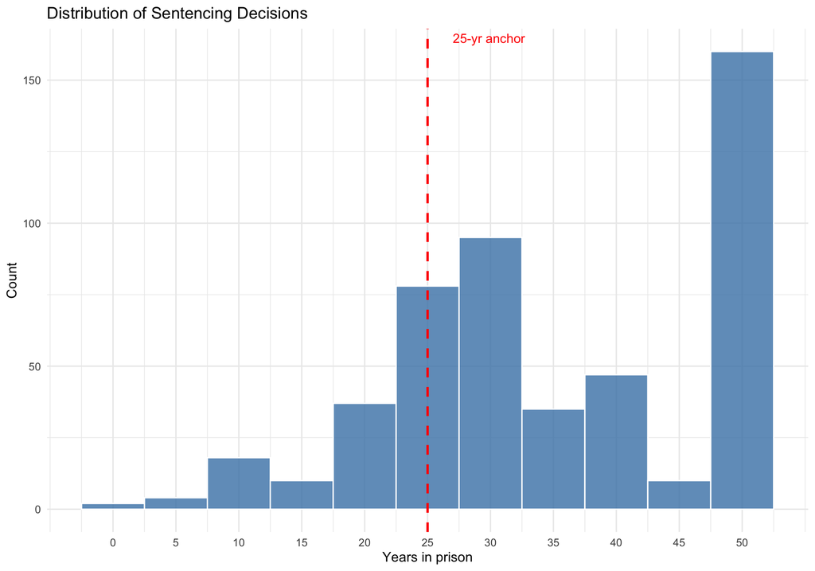

```r
# Display in knit
print(p_hist_overall)
```

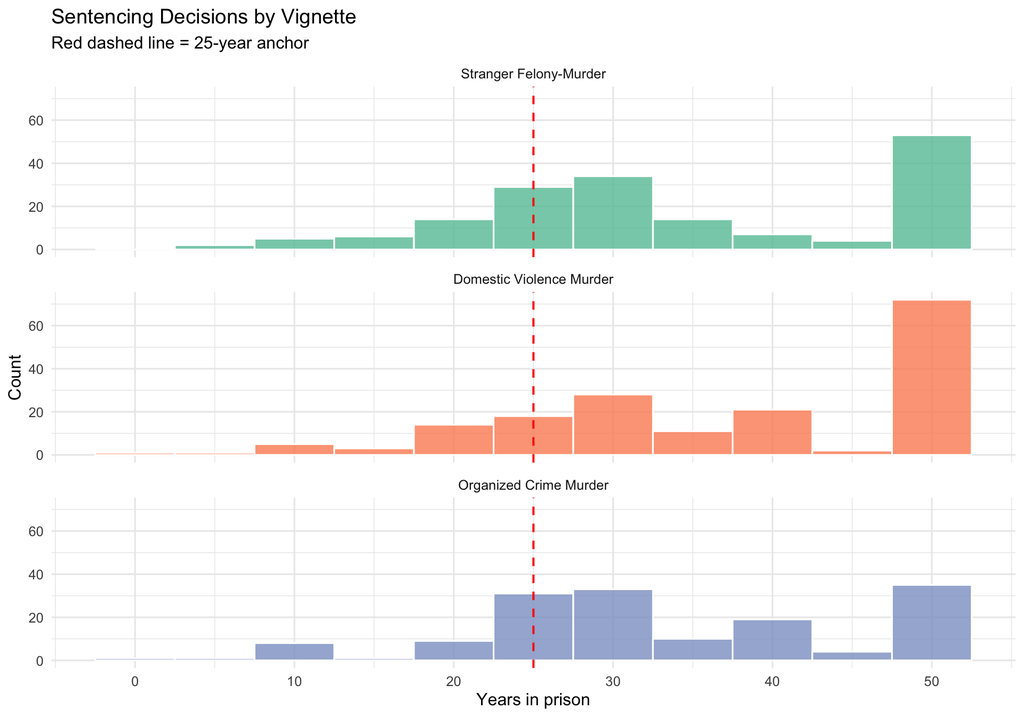

```r
print(p_hist_facet)
```

# PHASE 6: CONFIRMATORY HYPOTHESIS TESTS

This phase tests the three pre-registered hypotheses:

- **H1**: Punitiveness positively correlated with all correlate measures
- **H2**: Hostile aggression > Crime concerns in predicting punitiveness
- **H3**: Most correlate measures positively intercorrelated

## 6.1 H1: Punitiveness correlates with all measures

### 6.1a Cluster-level correlations

```r
cat("=== H1: CLUSTER-LEVEL CORRELATIONS ===\n\n")
```

```
## === H1: CLUSTER-LEVEL CORRELATIONS ===
```

```r
cluster_vars <- c("punitiveness_agg", "crime_concerns_agg", "process_agg",
                  "emotions_agg", "hostile_agg", "personality_agg")

# Display labels for clean output
cluster_labels <- c(
  "punitiveness_agg"   = "Punitiveness",
  "crime_concerns_agg" = "Crime Concerns",
  "process_agg"        = "Process Violations",
  "emotions_agg"       = "Emotions",
  "hostile_agg"        = "Hostile Aggression",
  "personality_agg"    = "Personality"
)

# Compute correlation matrix
cluster_data <- df_clean %>% select(all_of(cluster_vars)) %>% na.omit()
cluster_cor  <- corr.test(cluster_data, use = "pairwise", method = "pearson")

# Apply clean labels
colnames(cluster_cor$r) <- rownames(cluster_cor$r) <- cluster_labels[colnames(cluster_cor$r)]
colnames(cluster_cor$p) <- rownames(cluster_cor$p) <- cluster_labels[colnames(cluster_cor$p)]

cat("Correlation matrix (r):\n")
```

```
## Correlation matrix (r):
```

```r
print(round(cluster_cor$r, 2))
```

```
##                    Punitiveness Crime Concerns Process Violations Emotions
## Punitiveness               1.00           0.32               0.44     0.53
## Crime Concerns             0.32           1.00               0.38     0.43
## Process Violations         0.44           0.38               1.00     0.48
## Emotions                   0.53           0.43               0.48     1.00
## Hostile Aggression         0.59           0.38               0.59     0.69
## Personality                0.47           0.29               0.62     0.53
##                    Hostile Aggression Personality
## Punitiveness                     0.59        0.47
## Crime Concerns                   0.38        0.29
## Process Violations               0.59        0.62
## Emotions                         0.69        0.53
## Hostile Aggression               1.00        0.67
## Personality                      0.67        1.00
```

```r
cat("\nP-values:\n")
```

```
##
## P-values:
```

```r
print(round(cluster_cor$p, 4))
```

```
##                    Punitiveness Crime Concerns Process Violations Emotions
## Punitiveness                  0              0                  0        0
## Crime Concerns                0              0                  0        0
## Process Violations            0              0                  0        0
## Emotions                      0              0                  0        0
## Hostile Aggression            0              0                  0        0
## Personality                   0              0                  0        0
##                    Hostile Aggression Personality
## Punitiveness                        0           0
## Crime Concerns                      0           0
## Process Violations                  0           0
## Emotions                            0           0
## Hostile Aggression                  0           0
## Personality                         0           0
```

```r
# Punitiveness vs. each cluster (highlighted output)
cat("\n--- Punitiveness vs. Each Cluster ---\n")
```

```
##
## --- Punitiveness vs. Each Cluster ---
```

```r
for (var in cluster_vars[-1]) {
  r_val <- cor(df_clean$punitiveness_agg, df_clean[[var]],
               use = "pairwise.complete.obs")
  test  <- cor.test(df_clean$punitiveness_agg, df_clean[[var]])
  cat(sprintf("  %-22s r = %.2f, p %s\n",
              cluster_labels[var], r_val, format_p(test$p.value)))
}
```

```
##   Crime Concerns         r = 0.32, p < .001
##   Process Violations     r = 0.44, p < .001
##   Emotions               r = 0.53, p < .001
##   Hostile Aggression     r = 0.59, p < .001
##   Personality            r = 0.47, p < .001
```

```r
cat("\n")
```

### 6.1b Construct-level correlations

```r
cat("=== H1: CONSTRUCT-LEVEL CORRELATIONS ===\n\n")
```

```
## === H1: CONSTRUCT-LEVEL CORRELATIONS ===
```

```r
# All 18 correlate constructs + punitiveness DV
construct_vars_h1 <- c(
  "punitiveness_agg",
  # Crime Concerns
  "crime_rates_comp", "fear_comp",
  # Process Violations (exploratory)
  "dueprocess_comp", "uncertain_comp",
  # Emotions
  "hatred_comp", "anger_comp",
  # Hostile Aggression
  "exclusion_comp", "degradation_comp", "suffering_comp",
  "prisonvi_comp", "harsh_comp", "revenge_comp",
  # Personality
  "rwa_comp", "sdo_comp", "venge_comp", "vprone_comp",
  "raceresent_comp", "bloodsports_comp"
)

# Display labels
construct_labels <- c(
  "punitiveness_agg" = "Punitiveness",
  "crime_rates_comp" = "Crime Rates",
  "fear_comp"        = "Fear",
  "dueprocess_comp"  = "Due Process",
  "uncertain_comp"   = "Uncertain Evidence",
  "hatred_comp"      = "Hatred",
  "anger_comp"       = "Anger",
  "exclusion_comp"   = "Exclusion",
  "degradation_comp" = "Degradation",
  "suffering_comp"   = "Suffering",
  "prisonvi_comp"    = "Prison Violence",
  "harsh_comp"       = "Harsh Conditions",
  "revenge_comp"     = "Revenge",
  "rwa_comp"         = "RWA",
  "sdo_comp"         = "SDO",
  "venge_comp"       = "Vengefulness",
  "vprone_comp"      = "Violence Proneness",
  "raceresent_comp"  = "Racial Resentment",
  "bloodsports_comp" = "Blood Sports"
)

# Compute correlation matrix
construct_data_h1 <- df_clean %>% select(all_of(construct_vars_h1)) %>% na.omit()
construct_cor     <- corr.test(construct_data_h1, use = "pairwise", method = "pearson")

# Apply clean labels
colnames(construct_cor$r) <- rownames(construct_cor$r) <- construct_labels[colnames(construct_cor$r)]
colnames(construct_cor$p) <- rownames(construct_cor$p) <- construct_labels[colnames(construct_cor$p)]

# Extract the punitiveness row
punitiveness_cors <- data.frame(
  Construct = colnames(construct_cor$r)[-1],
  r         = construct_cor$r["Punitiveness", -1],
  p         = construct_cor$p["Punitiveness", -1]
) %>%
  mutate(
    r         = round(r, 2),
    sig       = sig_stars(p),
    Direction = ifelse(r > 0, "Positive", "Negative")
  ) %>%
  arrange(desc(abs(r)))

cat("Punitiveness correlations with constructs (sorted by |r|):\n")
```

```
## Punitiveness correlations with constructs (sorted by |r|):
```

```r
print(as.data.frame(punitiveness_cors), row.names = FALSE)
```

```
##           Construct    r                                           p sig
##    Harsh Conditions 0.56 0.00000000000000000000000000000000000000146 ***
##           Exclusion 0.54 0.00000000000000000000000000000000000088367 ***
##              Hatred 0.53 0.00000000000000000000000000000000003408773 ***
##           Suffering 0.52 0.00000000000000000000000000000000692216355 ***
##                 RWA 0.50 0.00000000000000000000000000000255468690156 ***
##   Racial Resentment 0.46 0.00000000000000000000000007576270968897927 ***
##               Anger 0.45 0.00000000000000000000000774325910360865235 ***
##         Degradation 0.44 0.00000000000000000000002751006908269931110 ***
##         Due Process 0.43 0.00000000000000000000050490585795064224687 ***
##             Revenge 0.43 0.00000000000000000000089296391036317302573 ***
##  Violence Proneness 0.41 0.00000000000000000004492528069221440832656 ***
##         Crime Rates 0.40 0.00000000000000000258996473346146174903954 ***
##  Uncertain Evidence 0.35 0.00000000000004045873073833809418642079117 ***
##     Prison Violence 0.35 0.00000000000006968182401471611736698009688 ***
##                 SDO 0.32 0.00000000001179328365267163918690994028362 ***
##                Fear 0.18 0.00132377313759396300976711735586377471918  **
##        Vengefulness 0.12 0.07367435580997361288524416522704996168613
##        Blood Sports 0.11 0.08017318731704685397243537181566352955997
##  Direction
##   Positive
##   Positive
##   Positive
##   Positive
##   Positive
##   Positive
##   Positive
##   Positive
##   Positive
##   Positive
##   Positive
##   Positive
##   Positive
##   Positive
##   Positive
##   Positive
##   Positive
##   Positive
```

```r
# H1 summary statistics
h1_n_positive     <- sum(punitiveness_cors$r > 0)
h1_n_total        <- nrow(punitiveness_cors)
h1_n_sig_positive <- sum(punitiveness_cors$r > 0 & punitiveness_cors$p < .05)

cat(sprintf("\n*** H1 SUMMARY (Construct Level) ***\n"))
```

```
##
## *** H1 SUMMARY (Construct Level) ***
```

```r
cat(sprintf("  Positive correlations:      %d/%d (%.1f%%)\n",
            h1_n_positive, h1_n_total, h1_n_positive / h1_n_total * 100))
```

```
##   Positive correlations:      18/18 (100.0%)
```

```r
cat(sprintf("  Significant positive (p<.05): %d/%d (%.1f%%)\n",
            h1_n_sig_positive, h1_n_total, h1_n_sig_positive / h1_n_total * 100))
```

```
##   Significant positive (p<.05): 16/18 (88.9%)
```

```r
cat(sprintf("  H1 SUPPORTED: %s\n\n",
            ifelse(h1_n_positive == h1_n_total, "YES (all positive)", "PARTIAL")))
```

```
##   H1 SUPPORTED: YES (all positive)
```

### 6.1c Item-level correlations

```r
cat("=== H1: ITEM-LEVEL CORRELATIONS WITH PUNITIVENESS ===\n\n")
```

```
## === H1: ITEM-LEVEL CORRELATIONS WITH PUNITIVENESS ===
```

```r
# All 56 individual correlate items (after reverse coding)
all_items <- c(
  # Crime Concerns
  "rates_1", "rates_2", "fear_1_R", "fear_2", "fear_3",
  # Emotions
  "hate_1", "hate_2_R", "hate_3", "anger_1", "anger_2",
  # Hostile Aggression
  "exclusion_1", "exclusion_2", "exclusion_3",
  "degrad_1_R", "degrad_2", "degrad_3",
  "suffer_1", "suffer_2",
  "prisonvi_1_R", "prisonvi_2_R",
  "harsh_1", "harsh_2_R", "harsh_3",
  "revenge_1", "revenge_2", "revenge_3",
  # Personality
  "rwa_1", "rwa_2", "rwa_3_R", "rwa_4", "rwa_5",
  "sdo_1", "sdo_2", "sdo_3_R", "sdo_4_R",
  "sdo_5", "sdo_6", "sdo_7_R", "sdo_8_R",
  "venge_1_R", "venge_2", "venge_3", "venge_4", "venge_5_R",
  "vprone_1", "vprone_2", "vprone_3", "vprone_4",
  "Raceresent_1_R", "Raceresent_2", "Raceresent_3", "Raceresent_4_R",
  "TV_4", "TV_6", "TV_8", "TV_9"
)

# Compute correlations and p-values
item_cors  <- sapply(all_items, function(item)
  cor(df_clean$punitiveness_agg, df_clean[[item]], use = "pairwise.complete.obs"))

item_pvals <- sapply(all_items, function(item)
  cor.test(df_clean$punitiveness_agg, df_clean[[item]])$p.value)

item_cor_df <- data.frame(
  Item = all_items,
  r    = round(item_cors, 2),
  p    = item_pvals,
  sig  = sig_stars(item_pvals)
) %>% arrange(desc(abs(r)))

cat(sprintf("Item-level correlations with punitiveness: %d items\n",
            length(all_items)))
```

```
## Item-level correlations with punitiveness: 56 items
```

```r
cat(sprintf("All positive: %s\n",
            ifelse(all(item_cors > 0), "YES", "NO")))
```

```
## All positive: YES
```

```r
cat(sprintf("Proportion positive: %.1f%%\n",
            mean(item_cors > 0) * 100))
```

```
## Proportion positive: 100.0%
```

```r
cat(sprintf("Significant (p < .05): %d/%d (%.1f%%)\n\n",
            sum(item_pvals < .05), length(item_pvals),
            sum(item_pvals < .05) / length(item_pvals) * 100))
```

```
## Significant (p < .05): 52/56 (92.9%)
```

```r
print(item_cor_df, row.names = FALSE)
```

```
##            Item    r                                                  p sig
##     exclusion_2 0.57 0.000000000000000000000000000000000000000000008673 ***
##           rwa_5 0.56 0.000000000000000000000000000000000000000003915383 ***
##     exclusion_1 0.51 0.000000000000000000000000000000000893779839284809 ***
##           rwa_4 0.51 0.000000000000000000000000000000000329561359651451 ***
##        suffer_1 0.49 0.000000000000000000000000000001171595690098784687 ***
##         harsh_3 0.49 0.000000000000000000000000000000180945590965485655 ***
##         harsh_1 0.48 0.000000000000000000000000000002260170266893789776 ***
##          hate_3 0.47 0.000000000000000000000000000161567571745959083511 ***
##    Raceresent_3 0.47 0.000000000000000000000000000158748105175485763232 ***
##        hate_2_R 0.46 0.000000000000000000000000003612360813061505020161 ***
##        suffer_2 0.46 0.000000000000000000000000010032374292518454254205 ***
##       harsh_2_R 0.46 0.000000000000000000000000007034067221986972506949 ***
##       revenge_2 0.45 0.000000000000000000000000119041409564984948593276 ***
##      degrad_1_R 0.44 0.000000000000000000000000495782066373279354950457 ***
##        degrad_3 0.44 0.000000000000000000000000347468058385977915932956 ***
##         anger_1 0.43 0.000000000000000000000007529743080306447549940342 ***
##           rwa_1 0.43 0.000000000000000000000002659790686400400563607873 ***
##        vprone_3 0.42 0.000000000000000000000092479139937558912363651821 ***
##    Raceresent_2 0.42 0.000000000000000000000077277728062174952252683273 ***
##         rates_2 0.41 0.000000000000000000000751264833741870545121618656 ***
##    prisonvi_1_R 0.41 0.000000000000000000000621305062970792526949995189 ***
##          hate_1 0.40 0.000000000000000000017797077327158911902556272328 ***
##         anger_2 0.40 0.000000000000000000027483887972700180815193854977 ***
##  Raceresent_4_R 0.38 0.000000000000000001304742479021260088766299619276 ***
##  Raceresent_1_R 0.36 0.000000000000000060298116268404206382013691409054 ***
##       revenge_1 0.34 0.000000000000016810655739821782202235660371074934 ***
##        vprone_1 0.33 0.000000000000093805193641621450577856695924850991 ***
##         rates_1 0.32 0.000000000000178002911398063616320577019905629011 ***
##           rwa_2 0.31 0.000000000001420540663683007319624112262910042549 ***
##           sdo_2 0.30 0.000000000007432408897794035326120380310589767737 ***
##           sdo_6 0.30 0.000000000008246009689180029411813023448261103857 ***
##         sdo_8_R 0.29 0.000000000076759171689115968953913939350577368137 ***
##           sdo_1 0.28 0.000000000152178346267032151230565578320440105198 ***
##         sdo_7_R 0.27 0.000000000980410516712645660882895764381712161439 ***
##     exclusion_3 0.25 0.000000008984252733375669725136051732301140093639 ***
##         rwa_3_R 0.24 0.000000039258998679226522534875358505512821238881 ***
##         sdo_3_R 0.24 0.000000047735679848068357361258001693091190809071 ***
##        vprone_4 0.24 0.000000039320984493472554209831645649284026511339 ***
##       revenge_3 0.23 0.000000342322883081961171091752013304065904719664 ***
##        vprone_2 0.23 0.000000269901497779964063425747625504791393780124 ***
##           sdo_5 0.22 0.000000923932765631802524002285769560982586767750 ***
##         sdo_4_R 0.18 0.000055320588955156419093926734031896330634481274 ***
##         venge_3 0.17 0.000128072935848782924750377532063794205896556377 ***
##        fear_1_R 0.15 0.000940901619810260579808425251968628799659200013 ***
##          fear_2 0.15 0.000574690363951751428603365035030492435907945037 ***
##          fear_3 0.15 0.001128088708634222446167139075612340093357488513  **
##    prisonvi_2_R 0.15 0.001024963594615675537002896788862926769070327282  **
##            TV_8 0.15 0.000715995549504559562759009594401504728011786938 ***
##        degrad_2 0.14 0.001429744983984780094810052020193325006403028965  **
##         venge_2 0.12 0.005762386154339120027112475241892752819694578648  **
##            TV_6 0.11 0.017125558231058046754213819440337829291820526123   *
##         venge_4 0.10 0.029654309640890177957039952616469236090779304504   *
##       venge_1_R 0.07 0.113735400225016866637695045483269495889544487000
##            TV_9 0.06 0.158566458731131149084703224616532679647207260132
##            TV_4 0.05 0.247282871294390416139208355161827057600021362305
##       venge_5_R 0.02 0.582353317261107505942163697909563779830932617188
```

```r
cat("\n")
```

### 6.1d Heatmap visualizations

```r
# --- Cluster-level heatmap ---
png(file.path(OUT_FIGURES, "heatmap_cluster_level.png"),
    width = 900, height = 900, res = 150)
corrplot(cluster_cor$r,
         method     = "color",
         type       = "upper",
         addCoef.col = "black",
         number.cex = 0.7,
         tl.col     = "black",
         tl.srt     = 45,
         tl.cex     = 0.75,
         p.mat      = cluster_cor$p,
         sig.level  = 0.05,
         insig      = "blank",
         title      = "Cluster-Level Correlations",
         mar        = c(0, 0, 2, 0))
dev.off()
```

```r
cat("Saved: heatmap_cluster_level.png\n")
```

```
## Saved: heatmap_cluster_level.png
```

```r
# --- Construct-level heatmap ---
png(file.path(OUT_FIGURES, "heatmap_construct_level.png"),
    width = 1400, height = 1400, res = 150)
corrplot(construct_cor$r,
         method     = "color",
         type       = "upper",
         addCoef.col = "black",
         number.cex = 0.45,
         tl.col     = "black",
         tl.srt     = 45,
         tl.cex     = 0.55,
         p.mat      = construct_cor$p,
         sig.level  = 0.05,
         insig      = "n",
         title      = "Construct-Level Correlations",
         mar        = c(0, 0, 2, 0))
dev.off()
```

```r
cat("Saved: heatmap_construct_level.png\n\n")
```

```
## Saved: heatmap_construct_level.png
```

### 6.1e 95% Confidence intervals for key cluster correlations

```r
cat("=== 95% CIs FOR KEY CLUSTER CORRELATIONS ===\n\n")
```

```
## === 95% CIs FOR KEY CLUSTER CORRELATIONS ===
```

```r
ci_table <- data.frame(
  Comparison = c("Punitiveness — Hostile Aggression",
                 "Punitiveness — Crime Concerns",
                 "Punitiveness — Emotions",
                 "Punitiveness — Personality",
                 "Punitiveness — Process Violations"),
  r          = NA, CI_Lower = NA, CI_Upper = NA, p = NA
)

ci_table[1, 2:5] <- get_cor_ci("punitiveness_agg", "hostile_agg",         df_clean)
ci_table[2, 2:5] <- get_cor_ci("punitiveness_agg", "crime_concerns_agg",  df_clean)
ci_table[3, 2:5] <- get_cor_ci("punitiveness_agg", "emotions_agg",        df_clean)
ci_table[4, 2:5] <- get_cor_ci("punitiveness_agg", "personality_agg",     df_clean)
ci_table[5, 2:5] <- get_cor_ci("punitiveness_agg", "process_agg",         df_clean)

ci_table <- ci_table %>% mutate(across(where(is.numeric), ~ round(., 3)))
print(as.data.frame(ci_table), row.names = FALSE)
```

```
##                         Comparison     r CI_Lower CI_Upper p
##  Punitiveness — Hostile Aggression 0.586    0.525    0.641 0
##      Punitiveness — Crime Concerns 0.322    0.240    0.398 0
##            Punitiveness — Emotions 0.535    0.469    0.595 0
##         Punitiveness — Personality 0.475    0.404    0.540 0
##  Punitiveness — Process Violations 0.439    0.365    0.508 0
```

```r
cat("\n")
```

## 6.2 H2: Hostile Aggression > Crime Concerns

This is the central confirmatory test. Steiger’s Z compares two **dependent** correlations (because both correlations share the punitiveness variable).

```r
cat("=== H2: HOSTILE AGGRESSION > CRIME CONCERNS ===\n\n")
```

```
## === H2: HOSTILE AGGRESSION > CRIME CONCERNS ===
```

```r
# The three correlations we need for Steiger's test
r_hostile       <- cor(df_clean$punitiveness_agg, df_clean$hostile_agg,
                       use = "pairwise.complete.obs")
r_crime         <- cor(df_clean$punitiveness_agg, df_clean$crime_concerns_agg,
                       use = "pairwise.complete.obs")
r_hostile_crime <- cor(df_clean$hostile_agg,      df_clean$crime_concerns_agg,
                       use = "pairwise.complete.obs")

cat(sprintf("r(Punitiveness, Hostile Aggression) = %.3f\n", r_hostile))
```

```
## r(Punitiveness, Hostile Aggression) = 0.586
```

```r
cat(sprintf("r(Punitiveness, Crime Concerns)     = %.3f\n", r_crime))
```

```
## r(Punitiveness, Crime Concerns)     = 0.322
```

```r
cat(sprintf("r(Hostile, Crime)                   = %.3f\n\n", r_hostile_crime))
```

```
## r(Hostile, Crime)                   = 0.380
```

```r
# Steiger's Z test using cocor for dependent overlapping correlations
n_steiger <- sum(complete.cases(df_clean[, c("punitiveness_agg",
                                              "hostile_agg",
                                              "crime_concerns_agg")]))
steiger_result <- cocor.dep.groups.overlap(
  r.jk = r_hostile,         # r(punitiveness, hostile)
  r.jh = r_crime,           # r(punitiveness, crime concerns)
  r.kh = r_hostile_crime,   # r(hostile, crime concerns)
  n    = n_steiger,
  test = "steiger1980"
)

cat("Steiger's Z-test for dependent correlations:\n")
```

```
## Steiger's Z-test for dependent correlations:
```

```r
cat(sprintf("  N = %d\n", n_steiger))
```

```
##   N = 496
```

```r
cat(sprintf("  r difference = %.3f − %.3f = %.3f\n",
            r_hostile, r_crime, r_hostile - r_crime))
```

```
##   r difference = 0.586 − 0.322 = 0.264
```

```r
print(steiger_result)
```

```
##
##   Results of a comparison of two overlapping correlations based on dependent groups
##
## Comparison between r.jk = 0.5858 and r.jh = 0.3216
## Difference: r.jk - r.jh = 0.2642
## Related correlation: r.kh = 0.3805
## Group size: n = 496
## Null hypothesis: r.jk is equal to r.jh
## Alternative hypothesis: r.jk is not equal to r.jh (two-sided)
## Alpha: 0.05
##
## steiger1980: Steiger's (1980) modification of Dunn and Clark's z (1969) using average correlations
##   z = 6.2614, p-value = 0.0000
##   Null hypothesis rejected
```

```r
# Extract p-value
h2_pvalue <- steiger_result@steiger1980$p.value

cat(sprintf("\n*** H2 SUMMARY ***\n"))
```

```
##
## *** H2 SUMMARY ***
```

```r
cat(sprintf("  Hostile Aggression r = %.3f\n", r_hostile))
```

```
##   Hostile Aggression r = 0.586
```

```r
cat(sprintf("  Crime Concerns r     = %.3f\n", r_crime))
```

```
##   Crime Concerns r     = 0.322
```

```r
cat(sprintf("  Difference           = %.3f\n", r_hostile - r_crime))
```

```
##   Difference           = 0.264
```

```r
cat(sprintf("  Steiger's Z p-value  = %.4f\n", h2_pvalue))
```

```
##   Steiger's Z p-value  = 0.0000
```

```r
cat(sprintf("  H2 SUPPORTED:        %s\n\n",
            ifelse(r_hostile > r_crime & h2_pvalue < .05,
                   "YES (significantly greater)", "NO")))
```

```
##   H2 SUPPORTED:        YES (significantly greater)
```

### 6.2b Extended H2 — All clusters vs. Crime Concerns

```r
cat("=== EXTENDED H2: ALL CLUSTERS vs. CRIME CONCERNS ===\n\n")
```

```
## === EXTENDED H2: ALL CLUSTERS vs. CRIME CONCERNS ===
```

```r
clusters_to_compare <- c("hostile_agg", "emotions_agg", "personality_agg", "process_agg")
cluster_labels_h2   <- c("Hostile Aggression", "Emotions", "Personality", "Process Violations")

# Collect results for export
extended_h2 <- data.frame(
  Cluster        = character(),
  r_Cluster      = numeric(),
  r_Crime        = numeric(),
  Difference     = numeric(),
  Steiger_p      = numeric(),
  Greater_p_lt05 = character(),
  stringsAsFactors = FALSE
)

for (i in seq_along(clusters_to_compare)) {
  r_other   <- cor(df_clean$punitiveness_agg, df_clean[[clusters_to_compare[i]]],
                   use = "pairwise.complete.obs")
  r_between <- cor(df_clean[[clusters_to_compare[i]]], df_clean$crime_concerns_agg,
                   use = "pairwise.complete.obs")

  steiger <- cocor.dep.groups.overlap(
    r.jk = r_other, r.jh = r_crime, r.kh = r_between,
    n    = n_steiger, test = "steiger1980"
  )

  cat(sprintf("%s vs Crime Concerns:\n", cluster_labels_h2[i]))
  cat(sprintf("  r(%s) = %.3f vs r(Crime) = %.3f\n",
              cluster_labels_h2[i], r_other, r_crime))
  cat(sprintf("  Difference = %.3f, p = %.4f\n",
              r_other - r_crime, steiger@steiger1980$p.value))
  cat(sprintf("  %s > Crime Concerns: %s\n\n", cluster_labels_h2[i],
              ifelse(steiger@steiger1980$p.value < .05 & r_other > r_crime,
                     "YES", "NO")))

  extended_h2 <- rbind(extended_h2, data.frame(
    Cluster        = cluster_labels_h2[i],
    r_Cluster      = round(r_other, 3),
    r_Crime        = round(r_crime, 3),
    Difference     = round(r_other - r_crime, 3),
    Steiger_p      = round(steiger@steiger1980$p.value, 4),
    Greater_p_lt05 = ifelse(steiger@steiger1980$p.value < .05 & r_other > r_crime,
                            "YES", "NO")
  ))
}
```

```
## Hostile Aggression vs Crime Concerns:
##   r(Hostile Aggression) = 0.586 vs r(Crime) = 0.322
##   Difference = 0.264, p = 0.0000
##   Hostile Aggression > Crime Concerns: YES
##
## Emotions vs Crime Concerns:
##   r(Emotions) = 0.535 vs r(Crime) = 0.322
##   Difference = 0.213, p = 0.0000
##   Emotions > Crime Concerns: YES
##
## Personality vs Crime Concerns:
##   r(Personality) = 0.475 vs r(Crime) = 0.322
##   Difference = 0.153, p = 0.0012
##   Personality > Crime Concerns: YES
##
## Process Violations vs Crime Concerns:
##   r(Process Violations) = 0.439 vs r(Crime) = 0.322
##   Difference = 0.117, p = 0.0091
##   Process Violations > Crime Concerns: YES
```

## 6.3 H3: Intercorrelations among correlates

```r
cat("=== H3: CORRELATES POSITIVELY INTERCORRELATED ===\n\n")
```

```
## === H3: CORRELATES POSITIVELY INTERCORRELATED ===
```

```r
# All 18 correlate constructs (excluding the punitiveness DV)
correlate_vars <- c(
  "crime_rates_comp", "fear_comp",
  "dueprocess_comp", "uncertain_comp",
  "hatred_comp", "anger_comp",
  "exclusion_comp", "degradation_comp", "suffering_comp",
  "prisonvi_comp", "harsh_comp", "revenge_comp",
  "rwa_comp", "sdo_comp", "venge_comp", "vprone_comp",
  "raceresent_comp", "bloodsports_comp"
)

correlate_data <- df_clean %>% select(all_of(correlate_vars)) %>% na.omit()
correlate_cor  <- corr.test(correlate_data, use = "pairwise", method = "pearson")

# Apply clean labels
colnames(correlate_cor$r) <- rownames(correlate_cor$r) <- construct_labels[colnames(correlate_cor$r)]
colnames(correlate_cor$p) <- rownames(correlate_cor$p) <- construct_labels[colnames(correlate_cor$p)]

# Count correlations: extract upper triangle (off-diagonal, no double-counting)
n_vars            <- length(correlate_vars)
h3_n_correlations <- (n_vars * (n_vars - 1)) / 2
upper_r           <- correlate_cor$r[upper.tri(correlate_cor$r)]
upper_p           <- correlate_cor$p[upper.tri(correlate_cor$p)]

h3_n_positive     <- sum(upper_r > 0)
h3_n_sig          <- sum(upper_p < .05)
h3_n_sig_positive <- sum(upper_r > 0 & upper_p < .05)

cat(sprintf("Total off-diagonal correlations: %d\n", h3_n_correlations))
```

```
## Total off-diagonal correlations: 153
```

```r
cat(sprintf("Positive correlations:           %d (%.1f%%)\n",
            h3_n_positive, h3_n_positive / h3_n_correlations * 100))
```

```
## Positive correlations:           153 (100.0%)
```

```r
cat(sprintf("Significant (p < .05):           %d (%.1f%%)\n",
            h3_n_sig, h3_n_sig / h3_n_correlations * 100))
```

```
## Significant (p < .05):           144 (94.1%)
```

```r
cat(sprintf("Significant AND positive:        %d (%.1f%%)\n",
            h3_n_sig_positive,
            h3_n_sig_positive / h3_n_correlations * 100))
```

```
## Significant AND positive:        144 (94.1%)
```

```r
cat(sprintf("\n*** H3 SUMMARY ***\n"))
```

```
##
## *** H3 SUMMARY ***
```

```r
cat(sprintf("  H3 SUPPORTED: %s\n\n",
            ifelse(h3_n_positive / h3_n_correlations > 0.5,
                   "YES (majority positive)", "NO")))
```

```
##   H3 SUPPORTED: YES (majority positive)
```

```r
# Full intercorrelation heatmap
png(file.path(OUT_FIGURES, "heatmap_intercorrelations.png"),
    width = 1600, height = 1600, res = 150)
corrplot(correlate_cor$r,
         method     = "color",
         type       = "upper",
         addCoef.col = "black",
         number.cex = 0.45,
         tl.col     = "black",
         tl.srt     = 45,
         tl.cex     = 0.55,
         p.mat      = correlate_cor$p,
         sig.level  = 0.05,
         insig      = "n",
         title      = "Intercorrelations Among Correlate Constructs",
         mar        = c(0, 0, 2, 0))
dev.off()
```

```r
cat("Saved: heatmap_intercorrelations.png\n\n")
```

```
## Saved: heatmap_intercorrelations.png
```

## 6.4 FDR correction

Given the 18 simultaneous tests for H1, we apply False Discovery Rate correction (Benjamini-Hochberg) to control the expected proportion of false positives.

```r
cat("=== FDR CORRECTION FOR MULTIPLE COMPARISONS ===\n\n")
```

```
## === FDR CORRECTION FOR MULTIPLE COMPARISONS ===
```

```r
# Apply FDR correction to all H1 construct-level p-values
all_pvalues  <- punitiveness_cors$p
fdr_adjusted <- p.adjust(all_pvalues, method = "fdr")

fdr_table <- punitiveness_cors %>%
  mutate(p_fdr   = round(fdr_adjusted, 4),
         sig_fdr = sig_stars(fdr_adjusted)) %>%
  select(Construct, r, p, sig, p_fdr, sig_fdr)

cat("H1 Results with FDR correction:\n")
```

```
## H1 Results with FDR correction:
```

```r
print(as.data.frame(fdr_table), row.names = FALSE)
```

```
##           Construct    r                                           p sig  p_fdr
##    Harsh Conditions 0.56 0.00000000000000000000000000000000000000146 *** 0.0000
##           Exclusion 0.54 0.00000000000000000000000000000000000088367 *** 0.0000
##              Hatred 0.53 0.00000000000000000000000000000000003408773 *** 0.0000
##           Suffering 0.52 0.00000000000000000000000000000000692216355 *** 0.0000
##                 RWA 0.50 0.00000000000000000000000000000255468690156 *** 0.0000
##   Racial Resentment 0.46 0.00000000000000000000000007576270968897927 *** 0.0000
##               Anger 0.45 0.00000000000000000000000774325910360865235 *** 0.0000
##         Degradation 0.44 0.00000000000000000000002751006908269931110 *** 0.0000
##         Due Process 0.43 0.00000000000000000000050490585795064224687 *** 0.0000
##             Revenge 0.43 0.00000000000000000000089296391036317302573 *** 0.0000
##  Violence Proneness 0.41 0.00000000000000000004492528069221440832656 *** 0.0000
##         Crime Rates 0.40 0.00000000000000000258996473346146174903954 *** 0.0000
##  Uncertain Evidence 0.35 0.00000000000004045873073833809418642079117 *** 0.0000
##     Prison Violence 0.35 0.00000000000006968182401471611736698009688 *** 0.0000
##                 SDO 0.32 0.00000000001179328365267163918690994028362 *** 0.0000
##                Fear 0.18 0.00132377313759396300976711735586377471918  ** 0.0015
##        Vengefulness 0.12 0.07367435580997361288524416522704996168613     0.0780
##        Blood Sports 0.11 0.08017318731704685397243537181566352955997     0.0802
##  sig_fdr
##      ***
##      ***
##      ***
##      ***
##      ***
##      ***
##      ***
##      ***
##      ***
##      ***
##      ***
##      ***
##      ***
##      ***
##      ***
##       **
##
##
```

```r
h1_n_sig_fdr <- sum(fdr_adjusted < .05 & punitiveness_cors$r > 0)
cat(sprintf("\nSignificant after FDR correction: %d/%d\n\n",
            h1_n_sig_fdr, nrow(fdr_table)))
```

```
##
## Significant after FDR correction: 16/18
```

# PHASE 7: CORRELATION TABLES FOR EXPORT

```r
cat("=== EXPORTING CORRELATION TABLES ===\n\n")
```

```
## === EXPORTING CORRELATION TABLES ===
```

```r
# --- Cluster-level table (printed) ---
cat("CLUSTER-LEVEL CORRELATION TABLE:\n\n")
```

```
## CLUSTER-LEVEL CORRELATION TABLE:
```

```r
cluster_table <- format_cor_table(cluster_cor$r, cluster_cor$p)
print(noquote(cluster_table))
```

```
##                    Punitiveness Crime Concerns Process Violations Emotions
## Punitiveness       -            0.32***        0.44***            0.53***
## Crime Concerns     0.32***      -              0.38***            0.43***
## Process Violations 0.44***      0.38***        -                  0.48***
## Emotions           0.53***      0.43***        0.48***            -
## Hostile Aggression 0.59***      0.38***        0.59***            0.69***
## Personality        0.47***      0.29***        0.62***            0.53***
##                    Hostile Aggression Personality
## Punitiveness       0.59***            0.47***
## Crime Concerns     0.38***            0.29***
## Process Violations 0.59***            0.62***
## Emotions           0.69***            0.53***
## Hostile Aggression -                  0.67***
## Personality        0.67***            -
```

```r
cat("\nNote: * p < .05, ** p < .01, *** p < .001\n\n")
```

```
##
## Note: * p < .05, ** p < .01, *** p < .001
```

```r
# --- Construct-level table (CSV only — too large to print) ---
write.csv(round(construct_cor$r, 2),
          file.path(OUT_TABLES, "correlation_table_construct_level.csv"))
cat("Saved: correlation_table_construct_level.csv\n")
```

```
## Saved: correlation_table_construct_level.csv
```

```r
write.csv(round(construct_cor$p, 4),
          file.path(OUT_TABLES, "pvalues_construct_level.csv"))
cat("Saved: pvalues_construct_level.csv\n")
```

```
## Saved: pvalues_construct_level.csv
```

```r
# --- Intercorrelation table (correlates only, no DV) ---
correlate_table <- format_cor_table(correlate_cor$r, correlate_cor$p)
write.csv(correlate_table,
          file.path(OUT_TABLES, "correlation_table_intercorrelations.csv"))
cat("Saved: correlation_table_intercorrelations.csv\n\n")
```

```
## Saved: correlation_table_intercorrelations.csv
```

# PHASE 8: VIGNETTE STABILITY SENSITIVITY ANALYSES

Although vignettes were randomly assigned, we test whether the substantive findings depend on which vignette participants saw. Results that hold across all three vignettes are more credible than those that emerge in only one.

## 8.1 Vignette effects on sentencing decisions

```r
cat("=== VIGNETTE EFFECTS ON SENTENCE ===\n\n")
```

```
## === VIGNETTE EFFECTS ON SENTENCE ===
```

```r
# One-way ANOVA testing whether vignette affects raw sentence length
anova_model <- aov(Sentence_1 ~ factor(vignette), data = df_clean)
cat("One-way ANOVA: Sentence ~ Vignette\n")
```

```
## One-way ANOVA: Sentence ~ Vignette
```

```r
print(summary(anova_model))
```

```
##                   Df Sum Sq Mean Sq F value Pr(>F)
## factor(vignette)   2   1492     746    4.84 0.0083 **
## Residuals        493  75951     154
## ---
## Signif. codes:  0 '***' 0.001 '**' 0.01 '*' 0.05 '.' 0.1 ' ' 1
```

```r
# Effect size (eta-squared)
eta_sq <- effectsize::eta_squared(anova_model)
cat("\nEffect size (eta-squared):\n")
```

```
##
## Effect size (eta-squared):
```

```r
print(as.data.frame(eta_sq))
```

```
##          Parameter    Eta2   CI   CI_low CI_high
## 1 factor(vignette) 0.01926 0.95 0.002889       1
```

```r
# Tukey HSD post-hoc comparisons
cat("\nTukey HSD post-hoc comparisons:\n")
```

```
##
## Tukey HSD post-hoc comparisons:
```

```r
print(TukeyHSD(anova_model))
```

```
##   Tukey multiple comparisons of means
##     95% family-wise confidence level
##
## Fit: aov(formula = Sentence_1 ~ factor(vignette), data = df_clean)
##
## $`factor(vignette)`
##       diff      lwr     upr  p adj
## 2-1  3.050 -0.09773  6.1968 0.0599
## 3-1 -1.003 -4.26915  2.2635 0.7507
## 3-2 -4.052 -7.28321 -0.8215 0.0094
```

```r
cat("\n")
```

## 8.2 Correlation stability across vignettes

```r
cat("=== CORRELATION STABILITY ACROSS VIGNETTES ===\n\n")
```

```
## === CORRELATION STABILITY ACROSS VIGNETTES ===
```

```r
# Compute punitiveness correlations separately within each vignette
compute_vignette_cors <- function(data, vignette_num) {
  subset_data <- data %>% filter(vignette == vignette_num)
  sapply(correlate_vars, function(var)
    cor(subset_data$punitiveness_agg, subset_data[[var]],
        use = "pairwise.complete.obs"))
}

vignette_cors <- data.frame(
  Construct  = construct_labels[correlate_vars],
  Vignette_1 = compute_vignette_cors(df_clean, 1),
  Vignette_2 = compute_vignette_cors(df_clean, 2),
  Vignette_3 = compute_vignette_cors(df_clean, 3)
)

# Add overall correlation for comparison
vignette_cors$Overall <- sapply(correlate_vars, function(var)
  cor(df_clean$punitiveness_agg, df_clean[[var]],
      use = "pairwise.complete.obs"))

# Round
vignette_cors <- vignette_cors %>%
  mutate(across(where(is.numeric), ~ round(., 2)))

cat("Punitiveness correlations by vignette:\n")
```

```
## Punitiveness correlations by vignette:
```

```r
print(as.data.frame(vignette_cors), row.names = FALSE)
```

```
##           Construct Vignette_1 Vignette_2 Vignette_3 Overall
##         Crime Rates       0.41       0.42       0.36    0.40
##                Fear       0.20       0.30       0.03    0.18
##         Due Process       0.45       0.45       0.39    0.43
##  Uncertain Evidence       0.29       0.37       0.42    0.35
##              Hatred       0.60       0.49       0.49    0.53
##               Anger       0.55       0.39       0.38    0.45
##           Exclusion       0.64       0.46       0.51    0.54
##         Degradation       0.52       0.41       0.38    0.44
##           Suffering       0.59       0.51       0.43    0.52
##     Prison Violence       0.31       0.39       0.35    0.35
##    Harsh Conditions       0.62       0.54       0.49    0.56
##             Revenge       0.51       0.40       0.37    0.43
##                 RWA       0.60       0.43       0.46    0.50
##                 SDO       0.36       0.32       0.28    0.32
##        Vengefulness       0.21       0.05       0.09    0.12
##  Violence Proneness       0.47       0.33       0.43    0.41
##   Racial Resentment       0.51       0.40       0.49    0.46
##        Blood Sports       0.12       0.10       0.12    0.11
```

```r
# Compute range across vignettes — large ranges indicate instability
vignette_cors$Range <- apply(
  vignette_cors[, c("Vignette_1", "Vignette_2", "Vignette_3")],
  1, function(x) max(x) - min(x)
)

cat("\n\nLargest ranges (least stable correlations):\n")
```

```
##
##
## Largest ranges (least stable correlations):
```

```r
print(as.data.frame(vignette_cors %>%
                    arrange(desc(Range)) %>%
                    head(5) %>%
                    select(Construct, Vignette_1, Vignette_2, Vignette_3, Range)),
      row.names = FALSE)
```

```
##  Construct Vignette_1 Vignette_2 Vignette_3 Range
##       Fear       0.20       0.30       0.03  0.27
##  Exclusion       0.64       0.46       0.51  0.18
##      Anger       0.55       0.39       0.38  0.17
##        RWA       0.60       0.43       0.46  0.17
##  Suffering       0.59       0.51       0.43  0.16
```

```r
cat("\n")
```

## 8.3 Mixed-effects model with vignette random intercept

```r
cat("=== MIXED-EFFECTS MODEL (Vignette as Random Intercept) ===\n\n")
```

```
## === MIXED-EFFECTS MODEL (Vignette as Random Intercept) ===
```

```r
# Model the central H2 relationship with vignette as a random intercept,
# allowing the baseline level of punitiveness to vary by vignette.
mixed_model <- lmer(punitiveness_agg ~ hostile_agg + (1 | vignette),
                    data = df_clean)

cat("Model: punitiveness_agg ~ hostile_agg + (1 | vignette)\n\n")
```

```
## Model: punitiveness_agg ~ hostile_agg + (1 | vignette)
```

```r
print(summary(mixed_model))
```

```
## Linear mixed model fit by REML. t-tests use Satterthwaite's method [
## lmerModLmerTest]
## Formula: punitiveness_agg ~ hostile_agg + (1 | vignette)
##    Data: df_clean
##
## REML criterion at convergence: 1008
##
## Scaled residuals:
##     Min      1Q  Median      3Q     Max
## -2.9325 -0.6919  0.0299  0.7368  2.6031
##
## Random effects:
##  Groups   Name        Variance Std.Dev.
##  vignette (Intercept) 0.000    0.000
##  Residual             0.439    0.662
## Number of obs: 496, groups:  vignette, 3
##
## Fixed effects:
##             Estimate Std. Error       df t value            Pr(>|t|)
## (Intercept)  -1.4958     0.0977 494.0000   -15.3 <0.0000000000000002 ***
## hostile_agg   0.3967     0.0247 494.0000    16.1 <0.0000000000000002 ***
## ---
## Signif. codes:  0 '***' 0.001 '**' 0.01 '*' 0.05 '.' 0.1 ' ' 1
##
## Correlation of Fixed Effects:
##             (Intr)
## hostile_agg -0.953
## optimizer (nloptwrap) convergence code: 0 (OK)
## boundary (singular) fit: see help('isSingular')
```

```r
# Compare to pure fixed-effects model
fixed_model <- lm(punitiveness_agg ~ hostile_agg, data = df_clean)
cat(sprintf("\nFixed-effects R²: %.3f\n", summary(fixed_model)$r.squared))
```

```
##
## Fixed-effects R²: 0.343
```

```r
# Intraclass correlation (proportion of variance attributable to vignette)
icc_result <- tryCatch({
  performance::icc(mixed_model)
}, warning = function(w) NULL, error = function(e) NULL)

if (is.null(icc_result) || is.atomic(icc_result)) {
  cat("ICC: Near zero (vignette accounts for negligible variance — singular fit)\n\n")
} else if (is.list(icc_result) && !is.null(icc_result$ICC_adjusted)) {
  cat(sprintf("ICC (Vignette): %.4f\n", icc_result$ICC_adjusted))
  cat("(Low ICC suggests vignette accounts for minimal variance)\n\n")
} else {
  cat("ICC: Could not be computed (likely near zero)\n\n")
}
```

```
## ICC: Near zero (vignette accounts for negligible variance — singular fit)
```

# PHASE 9: EXPLORATORY ANALYSES

## 9.1 Process Violations cluster (dropped from confirmatory)

```r
cat("=== PROCESS VIOLATIONS (EXPLORATORY) ===\n\n")
```

```
## === PROCESS VIOLATIONS (EXPLORATORY) ===
```

```r
# Punitiveness correlations
process_cor_due <- cor.test(df_clean$punitiveness_agg, df_clean$dueprocess_comp)
process_cor_unc <- cor.test(df_clean$punitiveness_agg, df_clean$uncertain_comp)
process_cor_agg <- cor.test(df_clean$punitiveness_agg, df_clean$process_agg)

cat("Punitiveness correlations with Process Violations:\n")
```

```
## Punitiveness correlations with Process Violations:
```

```r
cat(sprintf("  Due Process Violations:       r = %.2f, p %s\n",
            process_cor_due$estimate, format_p(process_cor_due$p.value)))
```

```
##   Due Process Violations:       r = 0.43, p < .001
```

```r
cat(sprintf("  Uncertain Evidence:           r = %.2f, p %s\n",
            process_cor_unc$estimate, format_p(process_cor_unc$p.value)))
```

```
##   Uncertain Evidence:           r = 0.35, p < .001
```

```r
cat(sprintf("  Process Violations Aggregate: r = %.2f, p %s\n\n",
            process_cor_agg$estimate, format_p(process_cor_agg$p.value)))
```

```
##   Process Violations Aggregate: r = 0.44, p < .001
```

```r
# Process Violations correlations with other clusters
cat("Process Violations correlations with other clusters:\n")
```

```
## Process Violations correlations with other clusters:
```

```r
process_cluster_vars <- c("crime_concerns_agg", "emotions_agg",
                          "hostile_agg", "personality_agg")
for (var in process_cluster_vars) {
  r <- cor(df_clean$process_agg, df_clean[[var]],
           use = "pairwise.complete.obs")
  cat(sprintf("  %-22s r = %.2f\n", cluster_labels[var], r))
}
```

```
##   Crime Concerns         r = 0.38
##   Emotions               r = 0.48
##   Hostile Aggression     r = 0.59
##   Personality            r = 0.62
```

```r
cat("\n")
```

## 9.2 Blood sports analysis

```r
cat("=== BLOOD SPORTS ANALYSIS ===\n\n")
```

```
## === BLOOD SPORTS ANALYSIS ===
```

```r
# Individual sport correlations with punitiveness
tv_sports <- c("TV_4", "TV_6", "TV_8", "TV_9")
tv_labels <- c("Boxing", "MMA / UFC", "Hunting", "Wrestling")

cat("Individual blood sport correlations with punitiveness:\n")
```

```
## Individual blood sport correlations with punitiveness:
```

```r
for (i in seq_along(tv_sports)) {
  r    <- cor(df_clean$punitiveness_agg, df_clean[[tv_sports[i]]],
              use = "pairwise.complete.obs")
  test <- cor.test(df_clean$punitiveness_agg, df_clean[[tv_sports[i]]])
  cat(sprintf("  %-12s r = %.2f, p %s\n",
              tv_labels[i], r, format_p(test$p.value)))
}
```

```
##   Boxing       r = 0.05, p = 0.247
##   MMA / UFC    r = 0.11, p = 0.017
##   Hunting      r = 0.15, p < .001
##   Wrestling    r = 0.06, p = 0.159
```

```r
cat(sprintf("\n  Blood Sports Composite: r = %.2f\n",
            cor(df_clean$punitiveness_agg, df_clean$bloodsports_comp,
                use = "pairwise.complete.obs")))
```

```
##
##   Blood Sports Composite: r = 0.11
```

```r
cat("\n")
```

## 9.3 Revenge (beliefs) vs. Vengefulness (personality trait)

These two constructs capture related but distinct phenomena: Revenge is a *belief* about whether punishment should serve retaliation, whereas Vengefulness is a *personality trait* — a stable disposition. We test whether they are statistically distinguishable predictors of punitiveness.

```r
cat("=== REVENGE (beliefs) vs. VENGEFULNESS (trait) ===\n\n")
```

```
## === REVENGE (beliefs) vs. VENGEFULNESS (trait) ===
```

```r
# Their correlation with each other
rev_veng_test <- cor.test(df_clean$revenge_comp, df_clean$venge_comp)
cat(sprintf("Correlation between constructs: r = %.3f, p %s\n",
            rev_veng_test$estimate, format_p(rev_veng_test$p.value)))
```

```
## Correlation between constructs: r = 0.458, p < .001
```

```r
cat(sprintf("95%% CI: [%.3f, %.3f]\n\n",
            rev_veng_test$conf.int[1], rev_veng_test$conf.int[2]))
```

```
## 95% CI: [0.386, 0.525]
```

```r
# Each with punitiveness
rev_pun_test  <- cor.test(df_clean$punitiveness_agg, df_clean$revenge_comp)
veng_pun_test <- cor.test(df_clean$punitiveness_agg, df_clean$venge_comp)

cat("Correlations with Punitiveness:\n")
```

```
## Correlations with Punitiveness:
```

```r
cat(sprintf("  Revenge (beliefs):    r = %.3f, p %s\n",
            rev_pun_test$estimate,  format_p(rev_pun_test$p.value)))
```

```
##   Revenge (beliefs):    r = 0.430, p < .001
```

```r
cat(sprintf("  Vengefulness (trait): r = %.3f, p %s\n\n",
            veng_pun_test$estimate, format_p(veng_pun_test$p.value)))
```

```
##   Vengefulness (trait): r = 0.119, p = 0.008
```

```r
# Steiger's Z to test whether one is a stronger predictor than the other
r_rev_veng <- cor(df_clean$revenge_comp, df_clean$venge_comp,
                  use = "pairwise.complete.obs")
n_rv       <- sum(complete.cases(df_clean[, c("punitiveness_agg",
                                              "revenge_comp",
                                              "venge_comp")]))
steiger_rv <- cocor.dep.groups.overlap(
  r.jk = rev_pun_test$estimate,
  r.jh = veng_pun_test$estimate,
  r.kh = r_rev_veng,
  n    = n_rv,
  test = "steiger1980"
)

cat("Steiger's Z (Revenge vs Vengefulness predicting Punitiveness):\n")
```

```
## Steiger's Z (Revenge vs Vengefulness predicting Punitiveness):
```

```r
cat(sprintf("  Difference = %.3f, p = %.4f\n",
            rev_pun_test$estimate - veng_pun_test$estimate,
            steiger_rv@steiger1980$p.value))
```

```
##   Difference = 0.311, p = 0.0000
```

```r
cat(sprintf("  Revenge significantly stronger: %s\n\n",
            ifelse(steiger_rv@steiger1980$p.value < .05 &
                   rev_pun_test$estimate > veng_pun_test$estimate,
                   "YES", "NO")))
```

```
##   Revenge significantly stronger: YES
```

## 9.4 Exploratory factor analysis

Pre-registered EFA on the 18 correlate constructs to examine the latent factor structure.

```r
cat("=== EXPLORATORY FACTOR ANALYSIS ===\n\n")
```

```
## === EXPLORATORY FACTOR ANALYSIS ===
```

```r
efa_vars <- correlate_vars
efa_data <- df_clean %>% select(all_of(efa_vars)) %>% na.omit()

cat(sprintf("Sample size for EFA:    N = %d\n", nrow(efa_data)))
```

```
## Sample size for EFA:    N = 496
```

```r
cat(sprintf("Variables:              k = %d\n", ncol(efa_data)))
```

```
## Variables:              k = 18
```

```r
cat(sprintf("Subjects per variable:  %.1f\n\n", nrow(efa_data) / ncol(efa_data)))
```

```
## Subjects per variable:  27.6
```

```r
# KMO Measure of Sampling Adequacy
kmo_result <- KMO(efa_data)
cat(sprintf("KMO Measure: %.3f\n", kmo_result$MSA))
```

```
## KMO Measure: 0.910
```

```r
cat("  (>.90 marvelous, >.80 meritorious, >.70 middling)\n\n")
```

```
##   (>.90 marvelous, >.80 meritorious, >.70 middling)
```

```r
# Parallel analysis to determine number of factors
cat("Parallel analysis (Horn's method):\n")
```

```
## Parallel analysis (Horn's method):
```

```r
parallel_result <- fa.parallel(efa_data, fa = "fa", n.iter = 100, show.legend = FALSE)
```

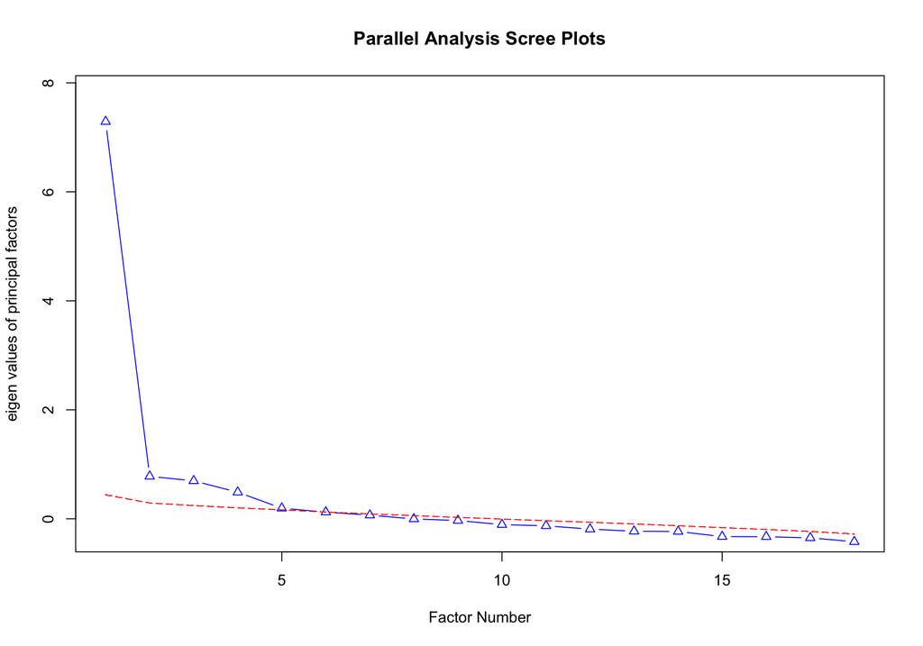

```
## Parallel analysis suggests that the number of factors =  4  and the number of components =  NA
```

```r
cat("\n")
```

```r
# Run EFA with the suggested number of factors
n_factors <- parallel_result$nfact
cat(sprintf("Running EFA with %d factors...\n\n", n_factors))
```

```
## Running EFA with 4 factors...
```

```r
efa_result <- fa(efa_data, nfactors = n_factors, rotate = "varimax", fm = "ml")

# Loadings (cutoff 0.3 for clarity)
cat("Factor loadings (sorted, |loading| > 0.3 shown):\n")
```

```
## Factor loadings (sorted, |loading| > 0.3 shown):
```

```r
print(efa_result$loadings, cutoff = 0.3, sort = TRUE)
```

```
##
## Loadings:
##                  ML1    ML2    ML3    ML4
## exclusion_comp    0.658  0.402
## degradation_comp  0.763
## suffering_comp    0.673                0.305
## prisonvi_comp     0.551         0.333
## harsh_comp        0.628  0.340  0.365
## revenge_comp      0.675
## crime_rates_comp         0.512
## hatred_comp       0.518  0.602
## anger_comp               0.909
## sdo_comp                        0.640
## raceresent_comp                 0.846
## bloodsports_comp                       0.546
## fear_comp                0.309
## dueprocess_comp   0.389                0.495
## uncertain_comp                  0.322  0.421
## rwa_comp                 0.390  0.473  0.414
## venge_comp        0.423                0.305
## vprone_comp       0.341         0.483  0.435
##
##                  ML1   ML2   ML3   ML4
## SS loadings    3.664 2.379 2.319 1.623
## Proportion Var 0.204 0.132 0.129 0.090
## Cumulative Var 0.204 0.336 0.465 0.555
```

```r
cat("\nVariance explained:\n")
```

```
##
## Variance explained:
```

```r
print(efa_result$Vaccounted)
```

```
##                          ML1    ML2    ML3     ML4
## SS loadings           3.6642 2.3786 2.3190 1.62342
## Proportion Var        0.2036 0.1321 0.1288 0.09019
## Cumulative Var        0.2036 0.3357 0.4645 0.55474
## Proportion Explained  0.3670 0.2382 0.2322 0.16258
## Cumulative Proportion 0.3670 0.6052 0.8374 1.00000
```

```r
cat("\n")
```

```r
# Save scree plot
png(file.path(OUT_FIGURES, "efa_scree_plot.png"),
    width = 800, height = 600, res = 150)
plot(efa_result$values, type = "b",
     main = "EFA Scree Plot",
     xlab = "Factor", ylab = "Eigenvalue")
abline(h = 1, lty = 2, col = "red")
dev.off()
```

```r
cat("Saved: efa_scree_plot.png\n\n")
```

```
## Saved: efa_scree_plot.png
```

## 9.5 Confirmatory factor analysis (pre-registered)

The five-factor CFA model corresponds to the theoretical clustering used throughout the analysis.

```r
cat("=== CONFIRMATORY FACTOR ANALYSIS ===\n\n")
```

```
## === CONFIRMATORY FACTOR ANALYSIS ===
```

```r
# Theoretical five-factor model
cfa_model <- '
  CrimeConcerns     =~ crime_rates_comp + fear_comp
  ProcessViolations =~ dueprocess_comp + uncertain_comp
  Emotions          =~ hatred_comp + anger_comp
  HostileAggression =~ exclusion_comp + degradation_comp + suffering_comp +
                       prisonvi_comp + harsh_comp + revenge_comp
  Personality       =~ rwa_comp + sdo_comp + venge_comp + vprone_comp +
                       raceresent_comp + bloodsports_comp
'

# Fit with ML, fall back to MLR (robust) if non-convergence
cfa_fit <- tryCatch({
  cfa(cfa_model, data = df_clean, std.lv = TRUE)
}, error = function(e) {
  cat("Standard CFA did not converge. Trying robust estimator (MLR)...\n")
  cfa(cfa_model, data = df_clean, std.lv = TRUE, estimator = "MLR")
})

# Fit indices
cat("CFA Model fit indices:\n")
```

```
## CFA Model fit indices:
```

```r
fit_indices <- fitMeasures(cfa_fit, c("chisq", "df", "pvalue",
                                       "cfi", "tli",
                                       "rmsea", "rmsea.ci.lower", "rmsea.ci.upper",
                                       "srmr"))
print(round(fit_indices, 3))
```

```
##          chisq             df         pvalue            cfi            tli
##        805.808        125.000          0.000          0.858          0.826
##          rmsea rmsea.ci.lower rmsea.ci.upper           srmr
##          0.105          0.098          0.112          0.064
```

```r
cat("\nInterpretation guidelines:\n")
```

```
##
## Interpretation guidelines:
```

```r
cat("  CFI/TLI > .90 acceptable, > .95 good\n")
```

```
##   CFI/TLI > .90 acceptable, > .95 good
```

```r
cat("  RMSEA < .08 acceptable, < .05 good\n")
```

```
##   RMSEA < .08 acceptable, < .05 good
```

```r
cat("  SRMR  < .08 acceptable\n\n")
```

```
##   SRMR  < .08 acceptable
```

```r
# Standardized factor loadings
cat("Standardized factor loadings:\n")
```

```
## Standardized factor loadings:
```

```r
std_solution <- standardizedSolution(cfa_fit) %>%
  filter(op == "=~") %>%
  select(Factor = lhs, Indicator = rhs, Loading = est.std, p = pvalue) %>%
  mutate(Loading = round(Loading, 3),
         p       = round(p, 4))
print(as.data.frame(std_solution), row.names = FALSE)
```

```
##             Factor        Indicator Loading p
##      CrimeConcerns crime_rates_comp   0.739 0
##      CrimeConcerns        fear_comp   0.531 0
##  ProcessViolations  dueprocess_comp   0.814 0
##  ProcessViolations   uncertain_comp   0.680 0
##           Emotions      hatred_comp   0.910 0
##           Emotions       anger_comp   0.788 0
##  HostileAggression   exclusion_comp   0.809 0
##  HostileAggression degradation_comp   0.830 0
##  HostileAggression   suffering_comp   0.831 0
##  HostileAggression    prisonvi_comp   0.554 0
##  HostileAggression       harsh_comp   0.843 0
##  HostileAggression     revenge_comp   0.745 0
##        Personality         rwa_comp   0.724 0
##        Personality         sdo_comp   0.674 0
##        Personality       venge_comp   0.380 0
##        Personality      vprone_comp   0.774 0
##        Personality  raceresent_comp   0.683 0
##        Personality bloodsports_comp   0.389 0
```

```r
# Factor correlations
cat("\nFactor correlations:\n")
```

```
##
## Factor correlations:
```

```r
factor_cors <- standardizedSolution(cfa_fit) %>%
  filter(op == "~~", lhs != rhs) %>%
  select(Factor1 = lhs, Factor2 = rhs, r = est.std) %>%
  mutate(r = round(r, 3))
print(as.data.frame(factor_cors), row.names = FALSE)
```

```
##            Factor1           Factor2     r
##      CrimeConcerns ProcessViolations 0.589
##      CrimeConcerns          Emotions 0.611
##      CrimeConcerns HostileAggression 0.540
##      CrimeConcerns       Personality 0.514
##  ProcessViolations          Emotions 0.626
##  ProcessViolations HostileAggression 0.755
##  ProcessViolations       Personality 0.794
##           Emotions HostileAggression 0.802
##           Emotions       Personality 0.649
##  HostileAggression       Personality 0.786
```

```r
cat("\n")
```

## 9.6 Demographic moderators

Per Dan’s Comment 433, we test whether punitiveness and sentencing decisions interact with key demographics (age, gender, education, race, political orientation).

```r
cat("=== DEMOGRAPHIC MODERATORS ===\n\n")
```

```
## === DEMOGRAPHIC MODERATORS ===
```

```r
# Recode political orientation into liberal / moderate / conservative
df_clean <- df_clean %>%
  mutate(political_group = case_when(
    politid <= 3 ~ "Liberal",
    politid == 4 ~ "Moderate",
    politid >= 5 ~ "Conservative"
  ))

# --- Political orientation ---
cat("POLITICAL ORIENTATION:\n")
```

```
## POLITICAL ORIENTATION:
```

```r
political_cors <- df_clean %>%
  group_by(political_group) %>%
  summarise(
    n             = n(),
    mean_punitive = round(mean(punitiveness_agg, na.rm = TRUE), 3),
    r_hostile     = round(cor(punitiveness_agg, hostile_agg,
                              use = "pairwise.complete.obs"), 3),
    r_crime       = round(cor(punitiveness_agg, crime_concerns_agg,
                              use = "pairwise.complete.obs"), 3),
    r_personality = round(cor(punitiveness_agg, personality_agg,
                              use = "pairwise.complete.obs"), 3),
    .groups       = "drop"
  )
print(as.data.frame(political_cors), row.names = FALSE)
```

```
##  political_group   n mean_punitive r_hostile r_crime r_personality
##     Conservative 190         0.259     0.560   0.196         0.389
##          Liberal 190        -0.313     0.574   0.353         0.413
##         Moderate 116         0.088     0.474   0.312         0.339
```

```r
cat("\n")
```

```r
# --- Gender ---
cat("GENDER:\n")
```

```
## GENDER:
```

```r
gender_cors <- df_clean %>%
  filter(gender %in% c(1, 2)) %>%
  mutate(gender_label = ifelse(gender == 1, "Male", "Female")) %>%
  group_by(gender_label) %>%
  summarise(
    n             = n(),
    mean_punitive = round(mean(punitiveness_agg, na.rm = TRUE), 3),
    r_hostile     = round(cor(punitiveness_agg, hostile_agg,
                              use = "pairwise.complete.obs"), 3),
    .groups       = "drop"
  )
print(as.data.frame(gender_cors), row.names = FALSE)
```

```
##  gender_label   n mean_punitive r_hostile
##        Female 249         0.094     0.589
##          Male 244        -0.104     0.599
```

```r
# T-test for gender difference in punitiveness
gender_ttest <- t.test(punitiveness_agg ~ gender,
                       data = df_clean %>% filter(gender %in% c(1, 2)))
cat(sprintf("\nGender difference: t(%.0f) = %.2f, p = %.3f\n",
            gender_ttest$parameter, gender_ttest$statistic,
            gender_ttest$p.value))
```

```
##
## Gender difference: t(491) = -2.71, p = 0.007
```

```r
gender_d <- effectsize::cohens_d(punitiveness_agg ~ gender,
                                 data = df_clean %>% filter(gender %in% c(1, 2)))
cat(sprintf("Cohen's d = %.2f\n\n", gender_d$Cohens_d))
```

```
## Cohen's d = -0.24
```

```r
# --- Age (continuous correlation) ---
cat("AGE (continuous):\n")
```

```
## AGE (continuous):
```

```r
age_pun_cor <- cor.test(df_clean$age_1, df_clean$punitiveness_agg)
cat(sprintf("  r(age, punitiveness)  = %.3f, p %s\n",
            age_pun_cor$estimate, format_p(age_pun_cor$p.value)))
```

```
##   r(age, punitiveness)  = -0.065, p = 0.146
```

```r
age_sent_cor <- cor.test(df_clean$age_1, df_clean$Sentence_1)
cat(sprintf("  r(age, sentence)      = %.3f, p %s\n\n",
            age_sent_cor$estimate, format_p(age_sent_cor$p.value)))
```

```
##   r(age, sentence)      = -0.054, p = 0.227
```

```r
# --- Education (continuous correlation) ---
cat("EDUCATION (continuous):\n")
```

```
## EDUCATION (continuous):
```

```r
edu_pun_cor <- cor.test(df_clean$education, df_clean$punitiveness_agg)
cat(sprintf("  r(education, punitiveness) = %.3f, p %s\n",
            edu_pun_cor$estimate, format_p(edu_pun_cor$p.value)))
```

```
##   r(education, punitiveness) = 0.007, p = 0.878
```

```r
edu_sent_cor <- cor.test(df_clean$education, df_clean$Sentence_1)
cat(sprintf("  r(education, sentence)     = %.3f, p %s\n\n",
            edu_sent_cor$estimate, format_p(edu_sent_cor$p.value)))
```

```
##   r(education, sentence)     = -0.049, p = 0.275
```

```r
# --- Race (one-way ANOVA) ---
cat("RACE (ANOVA):\n")
```

```
## RACE (ANOVA):
```

```r
race_anova <- aov(punitiveness_agg ~ factor(race), data = df_clean)
cat("  Punitiveness ~ Race:\n")
```

```
##   Punitiveness ~ Race:
```

```r
print(summary(race_anova))
```

```
##               Df Sum Sq Mean Sq F value Pr(>F)
## factor(race)   6      8   1.379     2.1  0.052 .
## Residuals    489    322   0.658
## ---
## Signif. codes:  0 '***' 0.001 '**' 0.01 '*' 0.05 '.' 0.1 ' ' 1
```

```r
race_anova_sent <- aov(Sentence_1 ~ factor(race), data = df_clean)
cat("\n  Sentence ~ Race:\n")
```

```
##
##   Sentence ~ Race:
```

```r
print(summary(race_anova_sent))
```

```
##               Df Sum Sq Mean Sq F value Pr(>F)
## factor(race)   6   2404     401    2.61  0.017 *
## Residuals    489  75039     153
## ---
## Signif. codes:  0 '***' 0.001 '**' 0.01 '*' 0.05 '.' 0.1 ' ' 1
```

```r
cat("\n")
```

```r
# --- Political × Hostile interaction (continuous politid) ---
cat("POLITICAL × HOSTILE INTERACTION:\n")
```

```
## POLITICAL × HOSTILE INTERACTION:
```

```r
political_int <- lm(punitiveness_agg ~ hostile_agg * politid, data = df_clean)
cat("Model: punitiveness_agg ~ hostile_agg * politid\n\n")
```

```
## Model: punitiveness_agg ~ hostile_agg * politid
```

```r
print(summary(political_int))
```

```
##
## Call:
## lm(formula = punitiveness_agg ~ hostile_agg * politid, data = df_clean)
##
## Residuals:
##     Min      1Q  Median      3Q     Max
## -1.8640 -0.4491  0.0089  0.4749  1.7324
##
## Coefficients:
##                     Estimate Std. Error t value             Pr(>|t|)
## (Intercept)          -1.9912     0.2073   -9.61 < 0.0000000000000002 ***
## hostile_agg           0.4468     0.0573    7.80    0.000000000000037 ***
## politid               0.1629     0.0479    3.40              0.00073 ***
## hostile_agg:politid  -0.0218     0.0122   -1.79              0.07398 .
## ---
## Signif. codes:  0 '***' 0.001 '**' 0.01 '*' 0.05 '.' 0.1 ' ' 1
##
## Residual standard error: 0.645 on 492 degrees of freedom
## Multiple R-squared:  0.379,  Adjusted R-squared:  0.375
## F-statistic:  100 on 3 and 492 DF,  p-value: <0.0000000000000002
```

```r
cat("\n")
```

# PHASE 10: MULTIPLE REGRESSION

## 10.1 All clusters predicting punitiveness

```r
cat("=== ALL CLUSTERS PREDICTING PUNITIVENESS ===\n\n")
```

```
## === ALL CLUSTERS PREDICTING PUNITIVENESS ===
```

```r
# Multi-cluster regression
cluster_reg <- lm(punitiveness_agg ~ crime_concerns_agg + process_agg +
                                     emotions_agg + hostile_agg + personality_agg,
                  data = df_clean)

cat("Model: Punitiveness ~ Crime + Process + Emotions + Hostile + Personality\n\n")
```

```
## Model: Punitiveness ~ Crime + Process + Emotions + Hostile + Personality
```

```r
print(summary(cluster_reg))
```

```
##
## Call:
## lm(formula = punitiveness_agg ~ crime_concerns_agg + process_agg +
##     emotions_agg + hostile_agg + personality_agg, data = df_clean)
##
## Residuals:
##     Min      1Q  Median      3Q     Max
## -1.8230 -0.4588  0.0146  0.4993  1.4830
##
## Coefficients:
##                    Estimate Std. Error t value             Pr(>|t|)
## (Intercept)         -1.9303     0.1241  -15.55 < 0.0000000000000002 ***
## crime_concerns_agg   0.0406     0.0285    1.43                0.154
## process_agg          0.0593     0.0389    1.53                0.128
## emotions_agg         0.1246     0.0306    4.08            0.0000534 ***
## hostile_agg          0.2127     0.0394    5.40            0.0000001 ***
## personality_agg      0.0717     0.0398    1.80                0.072 .
## ---
## Signif. codes:  0 '***' 0.001 '**' 0.01 '*' 0.05 '.' 0.1 ' ' 1
##
## Residual standard error: 0.641 on 490 degrees of freedom
## Multiple R-squared:  0.39,   Adjusted R-squared:  0.383
## F-statistic: 62.6 on 5 and 490 DF,  p-value: <0.0000000000000002
```

```r
# Standardized betas (re-fit with scaled variables)
cat("\nStandardized coefficients (β):\n")
```

```
##
## Standardized coefficients (β):
```

```r
cluster_reg_std <- lm(scale(punitiveness_agg) ~
                        scale(crime_concerns_agg) + scale(process_agg) +
                        scale(emotions_agg) + scale(hostile_agg) +
                        scale(personality_agg),
                      data = df_clean)
betas <- round(coef(cluster_reg_std)[-1], 3)
print(betas)
```

```
## scale(crime_concerns_agg)        scale(process_agg)       scale(emotions_agg)
##                     0.057                     0.073                     0.208
##        scale(hostile_agg)    scale(personality_agg)
##                     0.314                     0.092
```

```r
# Unique variance via Type-III ANOVA
cat("\nUnique variance explained (Type-III SS / total SS):\n")
```

```
##
## Unique variance explained (Type-III SS / total SS):
```

```r
anova_type3 <- Anova(cluster_reg, type = 3)
ss_total    <- sum(anova_type3$`Sum Sq`)
unique_var  <- anova_type3$`Sum Sq` / ss_total
names(unique_var) <- rownames(anova_type3)
print(round(unique_var[-1], 4))  # exclude intercept
```

```
## crime_concerns_agg        process_agg       emotions_agg        hostile_agg
##             0.0026             0.0030             0.0212             0.0371
##    personality_agg          Residuals
##             0.0041             0.6239
```

```r
cat("\n")
```

## 10.2 All constructs predicting punitiveness

```r
cat("=== ALL CONSTRUCTS PREDICTING PUNITIVENESS ===\n\n")
```

```
## === ALL CONSTRUCTS PREDICTING PUNITIVENESS ===
```

```r
construct_reg <- lm(punitiveness_agg ~
                      crime_rates_comp + fear_comp +
                      dueprocess_comp + uncertain_comp +
                      hatred_comp + anger_comp +
                      exclusion_comp + degradation_comp + suffering_comp +
                      prisonvi_comp + harsh_comp + revenge_comp +
                      rwa_comp + sdo_comp + venge_comp + vprone_comp +
                      raceresent_comp + bloodsports_comp,
                    data = df_clean)

cat("Full construct-level model summary:\n")
```

```
## Full construct-level model summary:
```

```r
print(summary(construct_reg))
```

```
##
## Call:
## lm(formula = punitiveness_agg ~ crime_rates_comp + fear_comp +
##     dueprocess_comp + uncertain_comp + hatred_comp + anger_comp +
##     exclusion_comp + degradation_comp + suffering_comp + prisonvi_comp +
##     harsh_comp + revenge_comp + rwa_comp + sdo_comp + venge_comp +
##     vprone_comp + raceresent_comp + bloodsports_comp, data = df_clean)
##
## Residuals:
##     Min      1Q  Median      3Q     Max
## -1.5987 -0.4074 -0.0139  0.4384  1.5275
##
## Coefficients:
##                  Estimate Std. Error t value             Pr(>|t|)
## (Intercept)      -1.82108    0.14046  -12.96 < 0.0000000000000002 ***
## crime_rates_comp  0.07249    0.02536    2.86              0.00444 **
## fear_comp        -0.00734    0.02408   -0.30              0.76069
## dueprocess_comp   0.06154    0.03323    1.85              0.06462 .
## uncertain_comp    0.00705    0.03274    0.22              0.82968
## hatred_comp       0.10116    0.03345    3.02              0.00263 **
## anger_comp       -0.01882    0.03046   -0.62              0.53709
## exclusion_comp    0.08399    0.03152    2.66              0.00797 **
## degradation_comp -0.06156    0.03441   -1.79              0.07420 .
## suffering_comp    0.06728    0.02808    2.40              0.01697 *
## prisonvi_comp     0.04238    0.02623    1.62              0.10682
## harsh_comp        0.05388    0.03171    1.70              0.08995 .
## revenge_comp      0.01848    0.02994    0.62              0.53732
## rwa_comp          0.05236    0.02600    2.01              0.04460 *
## sdo_comp         -0.06853    0.02657   -2.58              0.01020 *
## venge_comp       -0.04976    0.02351   -2.12              0.03480 *
## vprone_comp       0.03496    0.02843    1.23              0.21945
## raceresent_comp   0.08190    0.02262    3.62              0.00032 ***
## bloodsports_comp -0.04353    0.02025   -2.15              0.03204 *
## ---
## Signif. codes:  0 '***' 0.001 '**' 0.01 '*' 0.05 '.' 0.1 ' ' 1
##
## Residual standard error: 0.604 on 477 degrees of freedom
## Multiple R-squared:  0.472,  Adjusted R-squared:  0.452
## F-statistic: 23.7 on 18 and 477 DF,  p-value: <0.0000000000000002
```

```r
# Significant predictors
cat("\nSignificant predictors (p < .05), sorted by |β|:\n")
```

```
##
## Significant predictors (p < .05), sorted by |β|:
```

```r
construct_summary <- broom::tidy(construct_reg) %>%
  filter(p.value < .05, term != "(Intercept)") %>%
  arrange(desc(abs(estimate)))
print(as.data.frame(construct_summary), row.names = FALSE)
```

```
##              term estimate std.error statistic   p.value
##       hatred_comp  0.10116   0.03345     3.024 0.0026294
##    exclusion_comp  0.08399   0.03152     2.665 0.0079668
##   raceresent_comp  0.08190   0.02262     3.622 0.0003243
##  crime_rates_comp  0.07249   0.02536     2.859 0.0044371
##          sdo_comp -0.06853   0.02657    -2.579 0.0102005
##    suffering_comp  0.06728   0.02808     2.396 0.0169695
##          rwa_comp  0.05236   0.02600     2.014 0.0446022
##        venge_comp -0.04976   0.02351    -2.117 0.0347963
##  bloodsports_comp -0.04353   0.02025    -2.150 0.0320437
```

```r
cat("\n")
```

## 10.3 Hierarchical regression (incremental R²)

This regression progressively adds clusters in a theoretically motivated order: crime concerns first (the prosocially “legitimate” predictor), then process violations, hostile aggression, emotions, and finally personality. We track ΔR² at each step to quantify how much each cluster adds beyond the previous.

```r
cat("=== HIERARCHICAL REGRESSION ===\n\n")
```

```
## === HIERARCHICAL REGRESSION ===
```

```r
step1 <- lm(punitiveness_agg ~ crime_concerns_agg,                                    data = df_clean)
step2 <- lm(punitiveness_agg ~ crime_concerns_agg + process_agg,                      data = df_clean)
step3 <- lm(punitiveness_agg ~ crime_concerns_agg + process_agg + hostile_agg,        data = df_clean)
step4 <- lm(punitiveness_agg ~ crime_concerns_agg + process_agg + hostile_agg + emotions_agg, data = df_clean)
step5 <- lm(punitiveness_agg ~ crime_concerns_agg + process_agg + hostile_agg + emotions_agg + personality_agg, data = df_clean)

cat("Hierarchical regression results:\n")
```

```
## Hierarchical regression results:
```

```r
hierarchical_results <- data.frame(
  Step       = 1:5,
  Predictors = c("Crime Concerns",
                 "+ Process Violations",
                 "+ Hostile Aggression",
                 "+ Emotions",
                 "+ Personality"),
  R2         = c(summary(step1)$r.squared, summary(step2)$r.squared,
                 summary(step3)$r.squared, summary(step4)$r.squared,
                 summary(step5)$r.squared),
  Delta_R2   = c(summary(step1)$r.squared,
                 summary(step2)$r.squared - summary(step1)$r.squared,
                 summary(step3)$r.squared - summary(step2)$r.squared,
                 summary(step4)$r.squared - summary(step3)$r.squared,
                 summary(step5)$r.squared - summary(step4)$r.squared)
) %>%
  mutate(R2       = round(R2, 3),
         Delta_R2 = round(Delta_R2, 3))

print(hierarchical_results, row.names = FALSE)
```

```
##  Step           Predictors    R2 Delta_R2
##     1       Crime Concerns 0.103    0.103
##     2 + Process Violations 0.221    0.117
##     3 + Hostile Aggression 0.363    0.142
##     4           + Emotions 0.386    0.022
##     5        + Personality 0.390    0.004
```

```r
cat("\nModel comparison (ANOVA):\n")
```

```
##
## Model comparison (ANOVA):
```

```r
print(anova(step1, step2, step3, step4, step5))
```

```
## Analysis of Variance Table
##
## Model 1: punitiveness_agg ~ crime_concerns_agg
## Model 2: punitiveness_agg ~ crime_concerns_agg + process_agg
## Model 3: punitiveness_agg ~ crime_concerns_agg + process_agg + hostile_agg
## Model 4: punitiveness_agg ~ crime_concerns_agg + process_agg + hostile_agg +
##     emotions_agg
## Model 5: punitiveness_agg ~ crime_concerns_agg + process_agg + hostile_agg +
##     emotions_agg + personality_agg
##   Res.Df RSS Df Sum of Sq      F               Pr(>F)
## 1    494 296
## 2    493 257  1      38.7  94.29 < 0.0000000000000002 ***
## 3    492 210  1      47.0 114.27 < 0.0000000000000002 ***
## 4    491 203  1       7.4  17.97             0.000027 ***
## 5    490 201  1       1.3   3.24                0.072 .
## ---
## Signif. codes:  0 '***' 0.001 '**' 0.01 '*' 0.05 '.' 0.1 ' ' 1
```

```r
cat("\n")
```

# PHASE 11: SAVE ALL OUTPUT FILES

This phase writes all results to disk. The cleaned dataset is the canonical artifact that downstream scripts (NLP pipeline, supplementary analyses, manuscript figures) read from.

```r
cat("=== SAVING ALL OUTPUT FILES ===\n\n")
```

```
## === SAVING ALL OUTPUT FILES ===
```

```r
# === CLEANED DATASET ===
cleaned_path <- file.path(OUT_DATA, "punishment_212_cleaned_data.csv")
write.csv(df_clean, cleaned_path, row.names = FALSE)
cat(sprintf("Saved: %s\n", cleaned_path))
```

```
## Saved: data/cleaned/punishment_212_cleaned_data.csv
```

```r
cat(sprintf("       (%d rows × %d columns)\n\n", nrow(df_clean), ncol(df_clean)))
```

```
##        (496 rows × 145 columns)
```

```r
# === RELIABILITY TABLE ===
write.csv(alpha_table,
          file.path(OUT_TABLES, "reliability_alphas.csv"),
          row.names = FALSE)
cat("Saved: reliability_alphas.csv\n")
```

```
## Saved: reliability_alphas.csv
```

```r
# === DESCRIPTIVES ===
write.csv(descriptives_table,
          file.path(OUT_TABLES, "descriptive_statistics.csv"),
          row.names = FALSE)
cat("Saved: descriptive_statistics.csv\n")
```

```
## Saved: descriptive_statistics.csv
```

```r
# === SENTENCE BY VIGNETTE ===
write.csv(as.data.frame(sentence_vs_anchor),
          file.path(OUT_TABLES, "sentence_by_vignette.csv"),
          row.names = FALSE)
cat("Saved: sentence_by_vignette.csv\n")
```

```
## Saved: sentence_by_vignette.csv
```

```r
# === H1 RESULTS ===
write.csv(as.data.frame(fdr_table),
          file.path(OUT_TABLES, "H1_punitiveness_correlations.csv"),
          row.names = FALSE)
cat("Saved: H1_punitiveness_correlations.csv\n")
```

```
## Saved: H1_punitiveness_correlations.csv
```

```r
write.csv(item_cor_df,
          file.path(OUT_TABLES, "H1_item_level_correlations.csv"),
          row.names = FALSE)
cat("Saved: H1_item_level_correlations.csv\n")
```

```
## Saved: H1_item_level_correlations.csv
```

```r
# === H2 EXTENDED RESULTS ===
write.csv(extended_h2,
          file.path(OUT_TABLES, "h2_extended_steiger.csv"),
          row.names = FALSE)
cat("Saved: h2_extended_steiger.csv\n")
```

```
## Saved: h2_extended_steiger.csv
```

```r
# === VIGNETTE STABILITY ===
write.csv(as.data.frame(vignette_cors),
          file.path(OUT_TABLES, "vignette_correlation_stability.csv"),
          row.names = FALSE)
cat("Saved: vignette_correlation_stability.csv\n")
```

```
## Saved: vignette_correlation_stability.csv
```

```r
# === DEMOGRAPHIC RESULTS ===
write.csv(as.data.frame(political_cors),
          file.path(OUT_TABLES, "political_group_correlations.csv"),
          row.names = FALSE)
cat("Saved: political_group_correlations.csv\n")
```

```
## Saved: political_group_correlations.csv
```

```r
# === CFA RESULTS ===
write.csv(data.frame(Index = names(fit_indices),
                     Value = round(unname(fit_indices), 3)),
          file.path(OUT_TABLES, "cfa_fit_indices.csv"),
          row.names = FALSE)
cat("Saved: cfa_fit_indices.csv\n")
```

```
## Saved: cfa_fit_indices.csv
```

```r
write.csv(std_solution,
          file.path(OUT_TABLES, "cfa_standardized_loadings.csv"),
          row.names = FALSE)
cat("Saved: cfa_standardized_loadings.csv\n")
```

```
## Saved: cfa_standardized_loadings.csv
```

```r
write.csv(factor_cors,
          file.path(OUT_TABLES, "cfa_factor_correlations.csv"),
          row.names = FALSE)
cat("Saved: cfa_factor_correlations.csv\n")
```

```
## Saved: cfa_factor_correlations.csv
```

```r
# === REGRESSION RESULTS ===
write.csv(broom::tidy(cluster_reg),
          file.path(OUT_TABLES, "regression_clusters.csv"),
          row.names = FALSE)
cat("Saved: regression_clusters.csv\n")
```

```
## Saved: regression_clusters.csv
```

```r
write.csv(broom::tidy(construct_reg),
          file.path(OUT_TABLES, "regression_constructs.csv"),
          row.names = FALSE)
cat("Saved: regression_constructs.csv\n")
```

```
## Saved: regression_constructs.csv
```

```r
write.csv(hierarchical_results,
          file.path(OUT_TABLES, "hierarchical_regression.csv"),
          row.names = FALSE)
cat("Saved: hierarchical_regression.csv\n\n")
```

```
## Saved: hierarchical_regression.csv
```

# Summary of key findings

```r
cat(paste(rep("=", 70), collapse = ""), "\n")
cat("SUMMARY OF KEY FINDINGS\n")
```

```
## SUMMARY OF KEY FINDINGS
```

```r
cat(paste(rep("=", 70), collapse = ""), "\n\n")
cat("SAMPLE:\n")
```

```
## SAMPLE:
```

```r
cat(sprintf("  Final N = %d (of %d collected)\n", nrow(df_clean), n_raw))
```

```
##   Final N = 496 (of 514 collected)
```

```r
cat(sprintf("  Exclusions: %d total (%.1f%%)\n\n",
            n_raw - nrow(df_clean), 100 * (n_raw - nrow(df_clean)) / n_raw))
```

```
##   Exclusions: 18 total (3.5%)
```

```r
cat("HYPOTHESIS TESTS:\n\n")
```

```
## HYPOTHESIS TESTS:
```

```r
# H1
cat("H1: Punitiveness positively correlated with all correlates\n")
```

```
## H1: Punitiveness positively correlated with all correlates
```

```r
cat(sprintf("  Construct-level: %d/%d (%.1f%%) positive correlations\n",
            h1_n_positive, h1_n_total,
            h1_n_positive / h1_n_total * 100))
```

```
##   Construct-level: 18/18 (100.0%) positive correlations
```

```r
cat(sprintf("  Significant after FDR: %d/%d\n", h1_n_sig_fdr, h1_n_total))
```

```
##   Significant after FDR: 16/18
```

```r
cat(sprintf("  SUPPORTED: %s\n\n",
            ifelse(h1_n_positive / h1_n_total > 0.9, "YES", "PARTIAL")))
```

```
##   SUPPORTED: YES
```

```r
# H2
cat("H2: Hostile Aggression > Crime Concerns\n")
```

```
## H2: Hostile Aggression > Crime Concerns
```

```r
cat(sprintf("  r(Punitiveness, Hostile)  = %.3f\n", r_hostile))
```

```
##   r(Punitiveness, Hostile)  = 0.586
```

```r
cat(sprintf("  r(Punitiveness, Crime)    = %.3f\n", r_crime))
```

```
##   r(Punitiveness, Crime)    = 0.322
```

```r
cat(sprintf("  Difference                = %.3f\n", r_hostile - r_crime))
```

```
##   Difference                = 0.264
```

```r
cat(sprintf("  Steiger's Z p-value       = %.4f\n", h2_pvalue))
```

```
##   Steiger's Z p-value       = 0.0000
```

```r
cat(sprintf("  SUPPORTED: %s\n\n",
            ifelse(r_hostile > r_crime & h2_pvalue < .05,
                   "YES (Hostile Aggression > Crime Concerns)", "NO")))
```

```
##   SUPPORTED: YES (Hostile Aggression > Crime Concerns)
```

```r
# H3
cat("H3: Correlates positively intercorrelated\n")
```

```
## H3: Correlates positively intercorrelated
```

```r
cat(sprintf("  Positive correlations: %d/%d (%.1f%%)\n",
            h3_n_positive, h3_n_correlations,
            h3_n_positive / h3_n_correlations * 100))
```

```
##   Positive correlations: 153/153 (100.0%)
```

```r
cat(sprintf("  SUPPORTED: %s\n\n",
            ifelse(h3_n_positive / h3_n_correlations > 0.5, "YES", "NO")))
```

```
##   SUPPORTED: YES
```

```r
cat("KEY CORRELATES (Top 5 by |r|):\n")
```

```
## KEY CORRELATES (Top 5 by |r|):
```

```r
print(as.data.frame(head(punitiveness_cors %>% select(Construct, r, sig), 5)),
      row.names = FALSE)
```

```
##         Construct    r sig
##  Harsh Conditions 0.56 ***
##         Exclusion 0.54 ***
##            Hatred 0.53 ***
##         Suffering 0.52 ***
##               RWA 0.50 ***
```

```r
cat("\n")
```

```r
cat("REGRESSION SUMMARY:\n")
```

```
## REGRESSION SUMMARY:
```

```r
cat(sprintf("  Total R² (all clusters):       %.3f\n", summary(cluster_reg)$r.squared))
```

```
##   Total R² (all clusters):       0.390
```

```r
cat(sprintf("  Hostile Aggression unique var: %.3f\n", unique_var["hostile_agg"]))
```

```
##   Hostile Aggression unique var: 0.037
```

```r
cat("\n")
```

```r
cat(paste(rep("=", 70), collapse = ""), "\n")
cat("ANALYSIS COMPLETE\n")
```

```
## ANALYSIS COMPLETE
```

```r
cat(paste(rep("=", 70), collapse = ""), "\n")
```